# Đồ án cuối kỳ

Project 2 - CDC Diabetes Health Indicators

Nhóm 11

2025-01-14

# Library

```r
library(tidyverse)
library(ggplot2)
library(gridExtra)
library(themis)
library(caret)
library(dplyr)
library(lmPerm)
library(corrplot)
```

# I. Load Dataset

```r
data <- read_csv(file = 'diabetes_012_health_indicators_BRFSS2015.csv') |> janitor::clean_names()
```

```r
table(data['diabetes_012'])
```

```
## diabetes_012
##      0      1      2
## 213703   4631  35346
```

# II. EDA

## Explore Dataset

```r
glimpse(data)
```

```
## Rows: 253,680
## Columns: 22
## $ diabetes_012           <dbl> 0, 0, 0, 0, 0, 0, 0, 0, 2, 0, 2, 0, 0, 2, 0, 0,…
## $ high_bp                <dbl> 1, 0, 1, 1, 1, 1, 1, 1, 1, 0, 0, 1, 0, 1, 0, 1,…
## $ high_chol              <dbl> 1, 0, 1, 0, 1, 1, 0, 1, 1, 0, 0, 1, 0, 1, 1, 0,…
## $ chol_check             <dbl> 1, 0, 1, 1, 1, 1, 1, 1, 1, 1, 1, 1, 1, 1, 1, 1,…
## $ bmi                    <dbl> 40, 25, 28, 27, 24, 25, 30, 25, 30, 24, 25, 34,…
## $ smoker                 <dbl> 1, 1, 0, 0, 0, 1, 1, 1, 1, 0, 1, 1, 1, 0, 1, 0,…
## $ stroke                 <dbl> 0, 0, 0, 0, 0, 0, 0, 0, 0, 0, 0, 0, 0, 0, 1, 0,…
## $ heart_diseaseor_attack <dbl> 0, 0, 0, 0, 0, 0, 0, 0, 1, 0, 0, 0, 0, 0, 0, 0,…
## $ phys_activity          <dbl> 0, 1, 0, 1, 1, 1, 0, 1, 0, 0, 1, 0, 0, 0, 1, 1,…
## $ fruits                 <dbl> 0, 0, 1, 1, 1, 1, 0, 0, 1, 0, 1, 1, 0, 0, 0, 0,…
## $ veggies                <dbl> 1, 0, 0, 1, 1, 1, 0, 1, 1, 1, 1, 1, 1, 1, 1, 0,…
## $ hvy_alcohol_consump    <dbl> 0, 0, 0, 0, 0, 0, 0, 0, 0, 0, 0, 0, 0, 0, 0, 0,…
## $ any_healthcare         <dbl> 1, 0, 1, 1, 1, 1, 1, 1, 1, 1, 1, 1, 1, 1, 1, 1,…
## $ no_docbc_cost          <dbl> 0, 1, 1, 0, 0, 0, 0, 0, 0, 0, 0, 0, 0, 0, 1, 0,…
## $ gen_hlth               <dbl> 5, 3, 5, 2, 2, 2, 3, 3, 5, 2, 3, 3, 3, 4, 4, 2,…
## $ ment_hlth              <dbl> 18, 0, 30, 0, 3, 0, 0, 0, 30, 0, 0, 0, 0, 0, 30…
## $ phys_hlth              <dbl> 15, 0, 30, 0, 0, 2, 14, 0, 30, 0, 0, 30, 15, 0,…
## $ diff_walk              <dbl> 1, 0, 1, 0, 0, 0, 0, 1, 1, 0, 0, 1, 0, 1, 0, 0,…
## $ sex                    <dbl> 0, 0, 0, 0, 0, 1, 0, 0, 0, 1, 1, 0, 0, 0, 0, 0,…
## $ age                    <dbl> 9, 7, 9, 11, 11, 10, 9, 11, 9, 8, 13, 10, 7, 11…
## $ education              <dbl> 4, 6, 4, 3, 5, 6, 6, 4, 5, 4, 6, 5, 5, 4, 6, 6,…
## $ income                 <dbl> 3, 1, 8, 6, 4, 8, 7, 4, 1, 3, 8, 1, 7, 6, 2, 8,…
```

## Clean Dataset

- Kiểm tra dữ liệu có bị NA hay không

```r
sum(is.na(data))
```

```
## [1] 0
```

- Kiểm tra và xử lý dữ liệu bị trùng

```r
sum(duplicated(data))
```

```
## [1] 23899
```

```r
data_diabete <- unique(data)
sum(duplicated(data_diabete))
```

```
## [1] 0
```

## Preprocessing & Visualization

### Preprocessing

```r
#Các biến nhị phân (0, 1)
for (col in names(data_diabete)) {
  if (all(data_diabete[[col]] %in% c(0, 1))) {
    data_diabete[[col]] <- factor(data_diabete[[col]])
  }
}

#Các biến thang đo
data_diabete <- data_diabete |> mutate(gen_hlth = factor(gen_hlth))
data_diabete <- data_diabete |> mutate(age = factor(age))


#Biến tiểu đường
data_diabete <- data_diabete |> mutate(diabetes_012 = factor(diabetes_012))
```

```r
cor(data_diabete[, sapply(data_diabete, is.numeric)], use = "complete.obs")
```

```
##                   bmi   ment_hlth  phys_hlth   education      income
## bmi        1.00000000  0.06865296  0.1028439 -0.07456774 -0.06919217
## ment_hlth  0.06865296  1.00000000  0.3403616 -0.07642147 -0.18595253
## phys_hlth  0.10284389  0.34036159  1.0000000 -0.12799744 -0.24120987
## education -0.07456774 -0.07642147 -0.1279974  1.00000000  0.41935368
## income    -0.06919217 -0.18595253 -0.2412099  0.41935368  1.00000000
```

```r
data_diabete <- data_diabete |> mutate( education  = factor( education ))
data_diabete <- data_diabete |> mutate(income = factor(income))
```

```r
glimpse(data_diabete)
```

```
## Rows: 229,781
## Columns: 22
## $ diabetes_012           <fct> 0, 0, 0, 0, 0, 0, 0, 0, 2, 0, 2, 0, 0, 2, 0, 0,…
## $ high_bp                <fct> 1, 0, 1, 1, 1, 1, 1, 1, 1, 0, 0, 1, 0, 1, 0, 1,…
## $ high_chol              <fct> 1, 0, 1, 0, 1, 1, 0, 1, 1, 0, 0, 1, 0, 1, 1, 0,…
## $ chol_check             <fct> 1, 0, 1, 1, 1, 1, 1, 1, 1, 1, 1, 1, 1, 1, 1, 1,…
## $ bmi                    <dbl> 40, 25, 28, 27, 24, 25, 30, 25, 30, 24, 25, 34,…
## $ smoker                 <fct> 1, 1, 0, 0, 0, 1, 1, 1, 1, 0, 1, 1, 1, 0, 1, 0,…
## $ stroke                 <fct> 0, 0, 0, 0, 0, 0, 0, 0, 0, 0, 0, 0, 0, 0, 1, 0,…
## $ heart_diseaseor_attack <fct> 0, 0, 0, 0, 0, 0, 0, 0, 1, 0, 0, 0, 0, 0, 0, 0,…
## $ phys_activity          <fct> 0, 1, 0, 1, 1, 1, 0, 1, 0, 0, 1, 0, 0, 0, 1, 1,…
## $ fruits                 <fct> 0, 0, 1, 1, 1, 1, 0, 0, 1, 0, 1, 1, 0, 0, 0, 0,…
## $ veggies                <fct> 1, 0, 0, 1, 1, 1, 0, 1, 1, 1, 1, 1, 1, 1, 1, 0,…
## $ hvy_alcohol_consump    <fct> 0, 0, 0, 0, 0, 0, 0, 0, 0, 0, 0, 0, 0, 0, 0, 0,…
## $ any_healthcare         <fct> 1, 0, 1, 1, 1, 1, 1, 1, 1, 1, 1, 1, 1, 1, 1, 1,…
## $ no_docbc_cost          <fct> 0, 1, 1, 0, 0, 0, 0, 0, 0, 0, 0, 0, 0, 0, 1, 0,…
## $ gen_hlth               <fct> 5, 3, 5, 2, 2, 2, 3, 3, 5, 2, 3, 3, 3, 4, 4, 2,…
## $ ment_hlth              <dbl> 18, 0, 30, 0, 3, 0, 0, 0, 30, 0, 0, 0, 0, 0, 30…
## $ phys_hlth              <dbl> 15, 0, 30, 0, 0, 2, 14, 0, 30, 0, 0, 30, 15, 0,…
## $ diff_walk              <fct> 1, 0, 1, 0, 0, 0, 0, 1, 1, 0, 0, 1, 0, 1, 0, 0,…
## $ sex                    <fct> 0, 0, 0, 0, 0, 1, 0, 0, 0, 1, 1, 0, 0, 0, 0, 0,…
## $ age                    <fct> 9, 7, 9, 11, 11, 10, 9, 11, 9, 8, 13, 10, 7, 11…
## $ education              <fct> 4, 6, 4, 3, 5, 6, 6, 4, 5, 4, 6, 5, 5, 4, 6, 6,…
## $ income                 <fct> 3, 1, 8, 6, 4, 8, 7, 4, 1, 3, 8, 1, 7, 6, 2, 8,…
```

```r
sapply(data_diabete, function(x) length(unique(x)))
```

```
##           diabetes_012                high_bp              high_chol
##                      3                      2                      2
##             chol_check                    bmi                 smoker
##                      2                     84                      2
##                 stroke heart_diseaseor_attack          phys_activity
##                      2                      2                      2
##                 fruits                veggies    hvy_alcohol_consump
##                      2                      2                      2
##         any_healthcare          no_docbc_cost               gen_hlth
##                      2                      2                      5
##              ment_hlth              phys_hlth              diff_walk
##                     31                     31                      2
##                    sex                    age              education
##                      2                     13                      6
##                 income
##                      8
```

```r
data_summary <- data_diabete |>
  dplyr::select(where(is.numeric)) |>  # Lọc chỉ các biến định lượng
  summarise(
    across(
      everything(),
      list(
        gtnn = ~min(., na.rm = TRUE),
        gtln = ~max(., na.rm = TRUE),
        tv = ~median(., na.rm = TRUE),
        tb = ~mean(., na.rm = TRUE),
        dlc = ~sd(., na.rm = TRUE),
        iqr = ~IQR(., na.rm = TRUE)
      )
    )
  ) |>
  pivot_longer(
    cols = everything(),
    names_to = c("bien", "tk"),
    names_pattern = "^(.*)_(.*)$",
    values_to = "gt"
  ) |>
  pivot_wider(
    names_from = tk,
    values_from = gt
  ) |>
  dplyr::select(bien, gtnn, gtln, tv, tb, dlc, iqr)
data_summary
```

```
## # A tibble: 3 × 7
##   bien       gtnn  gtln    tv    tb   dlc   iqr
##   <chr>     <dbl> <dbl> <dbl> <dbl> <dbl> <dbl>
## 1 bmi          12    98    27 28.7   6.79     8
## 2 ment_hlth     0    30     0  3.51  7.71     2
## 3 phys_hlth     0    30     0  4.68  9.05     4
```

### Visualization

– Tổng quan phân phối của các biến

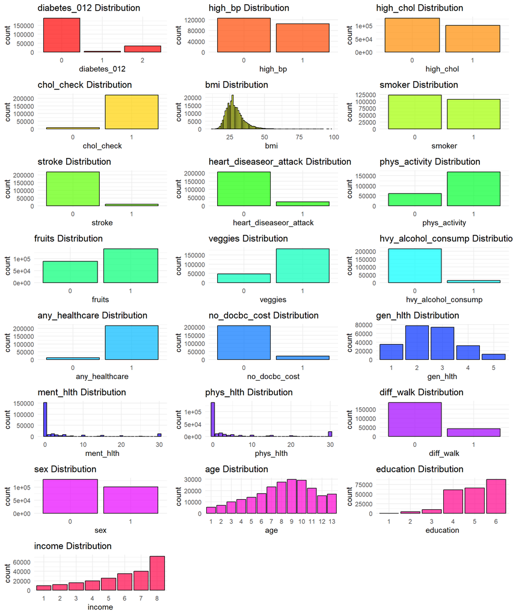

```r
# Cài đặt các thư viện cần thiết
renew_df <- data_diabete

cols <- colnames(renew_df)

set.seed(123)
colors <- grDevices::rainbow(length(cols))

plot_list <- list()

for (i in seq_along(cols)) {
col <- cols[i]
color <- colors[i]

p <- ggplot(renew_df, aes_string(x = col)) +
geom_bar(fill = color, color = "black", alpha = 0.7) +
labs(title = paste(col, "Distribution")) +
theme_minimal()

plot_list[[col]] <- p
}

do.call(grid.arrange, c(plot_list, ncol = 3))
```

– `high_bp` với `diabetes_012`

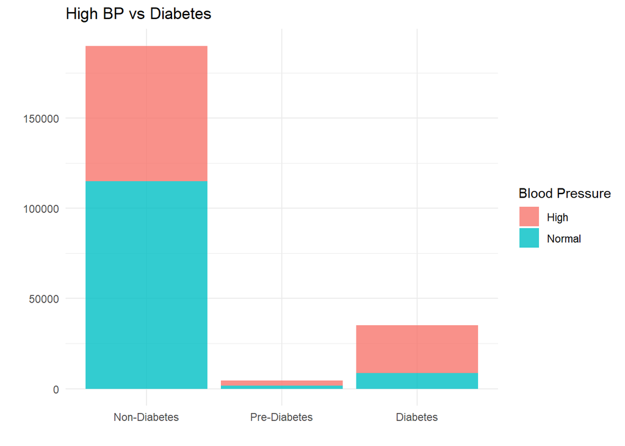

```r
#Vẽ biểu đồ kiểm tra những người bị tiểu đường thì huyết áp có cao không
data_diabete|>
  ggplot(aes(x = factor(diabetes_012, levels = c(0, 1, 2),
                       labels =  c("Non-Diabetes", "Pre-Diabetes", "Diabetes")),
             fill = factor(ifelse(high_bp == 1, "High", "Normal")))) +
  geom_bar(stat="count", alpha = 0.8) +
  labs(title = "High BP vs Diabetes",
       x = "",
       y = "",
       fill = "Blood Pressure") +
  theme_minimal()
```

```r
table(data_diabete$high_bp,data_diabete$diabetes_012)
```

```
##
##          0      1      2
##   0 114950   1717   8692
##   1  75105   2912  26405
```

**Nhận xét**

1. Non (0): Cao huyết áp ít hơn người bình thường 39.52%.
2. Pre (1): Cao huyết áp nhiều hơn người bình thường 62,9%.
3. Diabete (2): Cao huyết áp nhiều hơn người bình thường 75,24%.

Vậy, tình trạng cao huyết áp phổ biến ở người tiểu đường và tiền tiểu đường.

– `high_chol` và `diabetes_012`

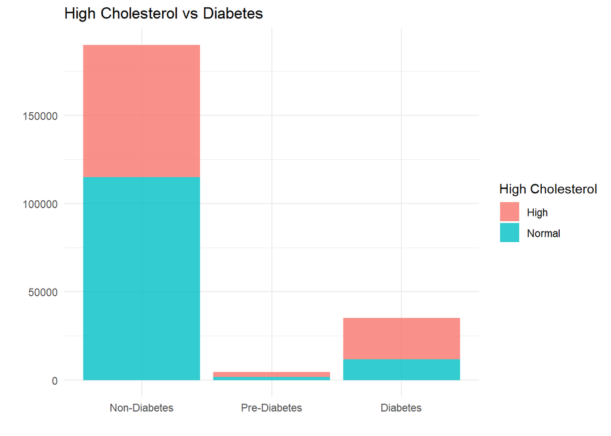

```r
#Vẽ biểu đồ kiểm tra những người bị tiểu đường thì có bị cao cholesterol hay không
data_diabete |>
  ggplot(aes(x = factor(diabetes_012, levels = c(0, 1, 2),
                       labels =  c("Non-Diabetes", "Pre-Diabetes", "Diabetes")),
             fill = factor(ifelse(high_chol == 1, "High", "Normal")))) +
  geom_bar(stat="count", alpha = 0.8) +
  labs(title = "High Cholesterol vs Diabetes",
       x = "",
       y = "",
       fill = "High Cholesterol") +
  theme_minimal()
```

```r
table(data_diabete$high_chol,data_diabete$diabetes_012)
```

```
##
##          0      1      2
##   0 114917   1755  11601
##   1  75138   2874  23496
```

**Nhận xét**

1. Non (0): Người có lượng cholesterol cao chiếm khoảng 39,53%.
2. Pre (1): Người có lượng cholesterol cao chiếm khoảng 62,09%.
3. Diabetes (2):Người có lượng cholesterol cao chiếm khoảng 66,95%.

Suy ra, người có lượng cholesterol cao thường là người tiểu đường và tiền tiểu đường.

– `smoker` với `diabetes_012`

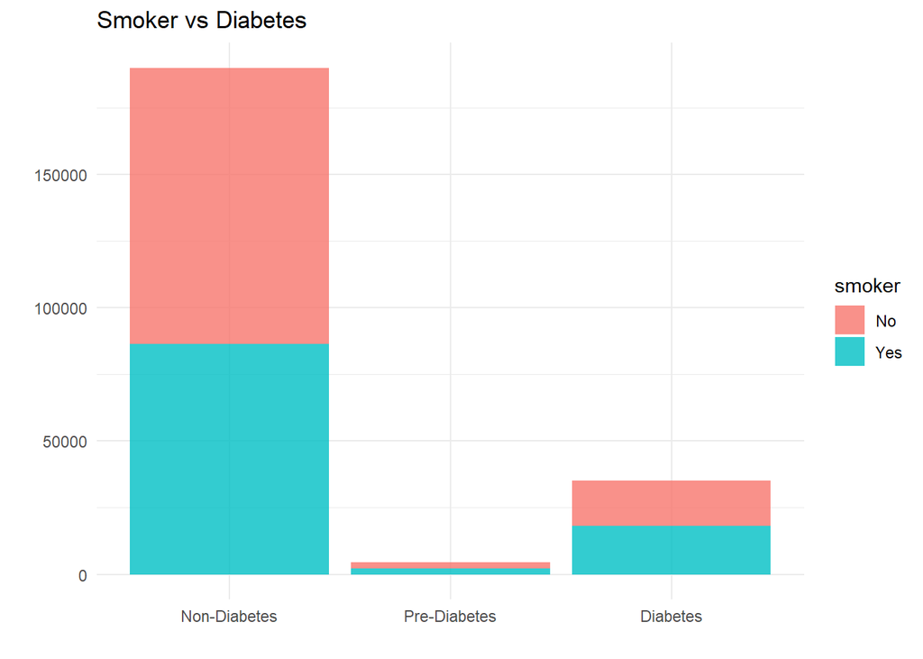

```r
#Vẽ biểu đồ kiểm tra những người bị tiểu đường thì có hút thuốc hay không
data_diabete |>
  ggplot(aes(x = factor(diabetes_012, levels = c(0, 1, 2),
                       labels =  c("Non-Diabetes", "Pre-Diabetes", "Diabetes")),
             fill = factor(ifelse(smoker == 1, "Yes", "No")))) +
  geom_bar(stat="count", alpha = 0.8) +
  labs(title = "Smoker vs Diabetes",
       x = "",
       y = "",
       fill = "smoker") +
  theme_minimal()
```

```r
table(data_diabete$smoker,data_diabete$diabetes_012)
```

```
##
##          0      1      2
##   0 103559   2348  16874
##   1  86496   2281  18223
```

**Nhận xét**

1. Non (0): Người có hút thuốc chiếm khoảng 45,51%.
2. Pre (1): Người có hút thuốc chiếm khoảng 49,28%.
3. Diabete (2): Người có hút thuốc chiếm khoảng 51,92%%.

Tỉ lệ hút thuốc các nhóm không chênh lệch nhiều, suy ra biến `smoker` có thể không ảnh hưởng tới biến mục tiêu.

– `stroke` với `diabetes_012`

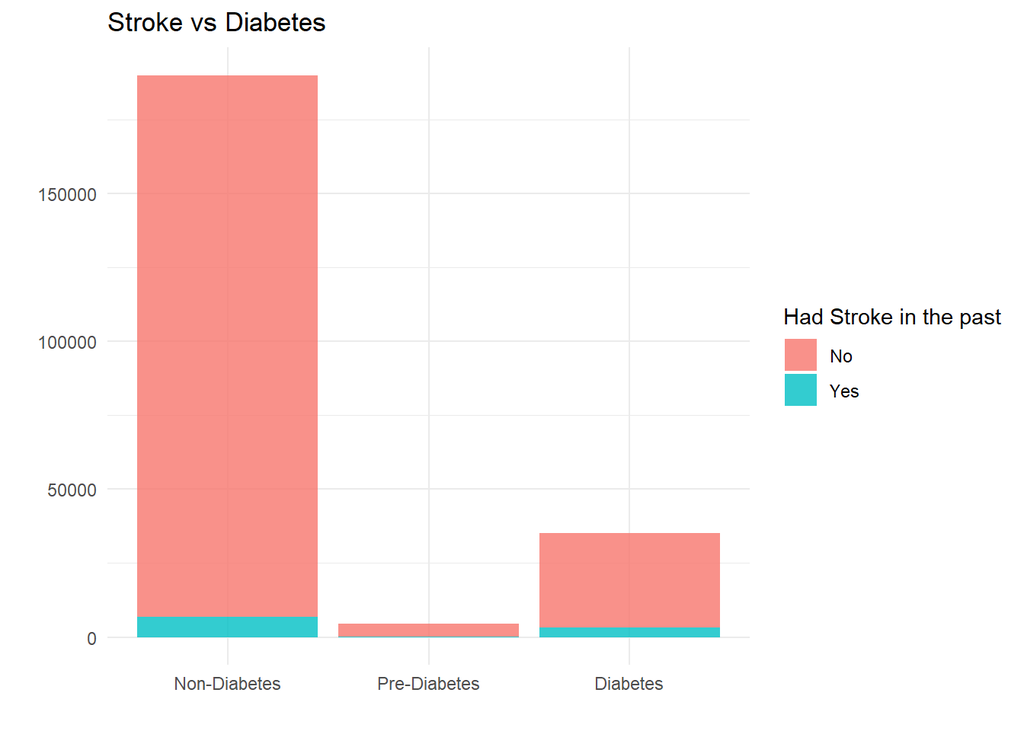

```r
# Stroke có liên quan không?
# Vẽ biểu đồ kiểm tra sự liên quan giữa stroke và diabetes_012
data_diabete |>
  ggplot(aes(x = factor(diabetes_012, levels = c(0, 1, 2),
                       labels = c("Non-Diabetes", "Pre-Diabetes", "Diabetes")),
             fill = factor(ifelse(stroke == 0, "No", "Yes")))) +
  geom_bar(stat="count", alpha = 0.8) +
  labs(title = "Stroke vs Diabetes",
       x = "",
       y = "",
       fill = "Had Stroke in the past") +
  theme_minimal()
```

```r
table(data_diabete$stroke,data_diabete$diabetes_012)
```

```
##
##          0      1      2
##   0 183304   4364  31829
##   1   6751    265   3268
```

**Nhận xét**

1. Non (0): Người đã từng đột quỵ chiếm khoảng 3,55%.
2. Pre (1): Người đã từng đột quỵ chiếm khoảng 5,72%.
3. Diabete (2): Người đã từng đột quỵ chiếm khoảng 9,31%.

– `sex` với `diabetes_012`

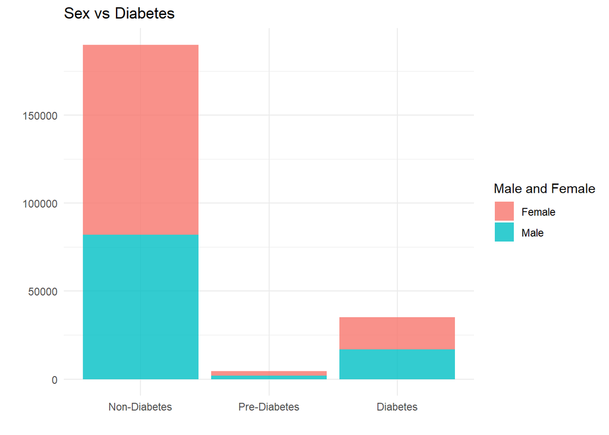

```r
#Sex
#Vẽ biểu đồ kiểm tra liệu giới tính có liên quan tới khả năng mắc bệnh tiểu đường
data_diabete |>
  ggplot(aes(x = factor(diabetes_012, levels = c(0, 1, 2),
                       labels = c("Non-Diabetes", "Pre-Diabetes", "Diabetes")),
             fill = factor(ifelse(sex == 1, "Male", "Female")))) +
  geom_bar(stat="count", alpha = 0.8) +
  labs(title = "Sex vs Diabetes",
       x = "",
       y = "",
       fill = "Male and Female") +
  theme_minimal()
```

```r
table(data_diabete$sex,data_diabete$diabetes_012)
```

```
##
##          0      1      2
##   0 107905   2604  18345
##   1  82150   2025  16752
```

**Nhận xét**

1. Non (0): Nam chiếm khoảng 43,22%, nữ là 56,78%.
2. Pre (1): Nam chiếm khoảng 43,75%, nữ là 56,25%.
3. Diabete (2):Nam chiếm khoảng 47,73%%, nữ là 52,27%.

Suy ra, ta thấy số người mắc bệnh tuổi đường ở nữ cao hơn. Nhưng sự chênh lệch tỉ lệ nam và nữ ở các nhóm không nhiều.

– `bmi` và `diabetes_012`

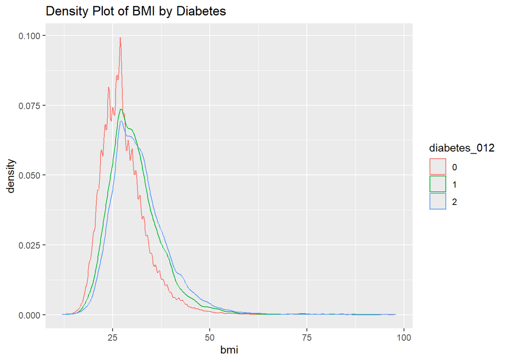

```r
#BMI
ggplot(data_diabete, aes(x = bmi,color = diabetes_012)) +
  geom_density(alpha = 0.5) +
  labs(title = "Density Plot of BMI by Diabetes ")
```

```r
data_diabete_copy <- data_diabete

# Chia các mức chỉ số BMI và thêm vào bản sao
data_diabete_copy$bmi <- cut(data_diabete_copy$bmi,
                                   breaks = c(-Inf, 18.5, 24.9, 29.9, 34.9, 39.9, Inf),
                                   labels = c("Underweight", "Healthy Weight", "Overweight",
                                              "Obese", "Severely Obese", "Morbidly Obese"),
                                   right = FALSE)
```

**Nhận xét:** từ biểu đồ ta thấy được những người Pre-Diabetes và Diabetes có BMI cao hơn so với những người không mắc bệnh.

```r
table(data_diabete_copy$bmi,data_diabete$diabetes_012)
```

```
##
##                      0     1     2
##   Underweight     2856    28   169
##   Healthy Weight 54328   689  3910
##   Overweight     70770  1524 10565
##   Obese          39257  1315 10193
##   Severely Obese 14160   648  5653
##   Morbidly Obese  8684   425  4607
```

**Nhận xét**

+ Người ở nhóm gầy rất ít người bị tiểu đường

+ Người từ mức thừa cân trở lên nguy cơ bị tiểu đường cao

– `age` và `diabetes_012`

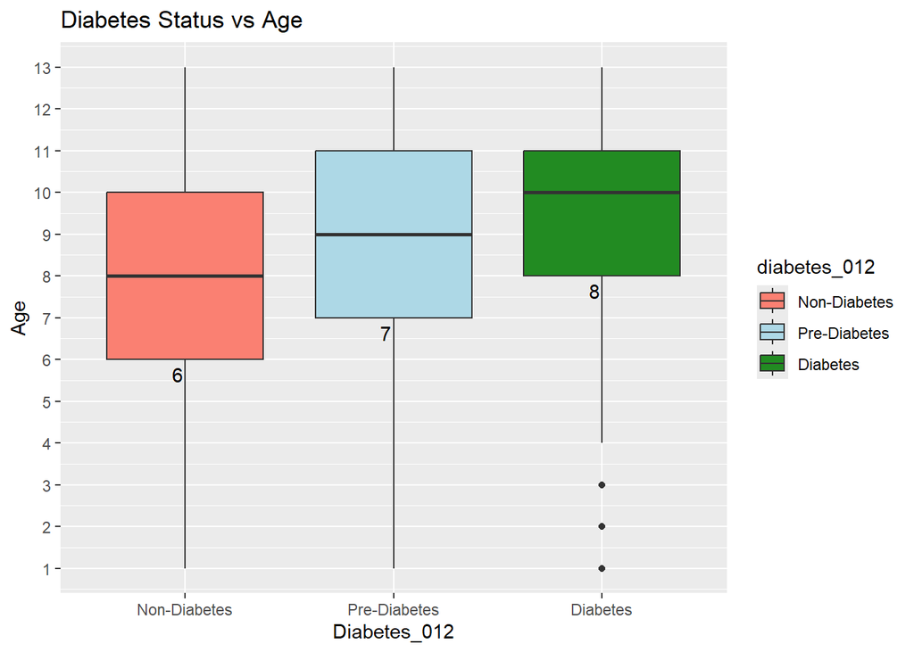

```r
q1_data <- data_diabete |>
  group_by(diabetes_012) |>
  summarise(Q1 = quantile(as.numeric(age), 0.25, na.rm = TRUE))

ggplot(data = data_diabete, aes(x = diabetes_012, y = as.numeric(age), fill = diabetes_012)) +
  geom_boxplot() +
  labs(title = "Diabetes Status vs Age", x = "Diabetes_012", y = "Age") +
  scale_fill_manual(values = c("salmon", "lightblue", "forestgreen"), labels = c("Non-Diabetes", "Pre-Diabetes", "Diabetes")) +
  scale_x_discrete(labels = c("0" = "Non-Diabetes", "1" = "Pre-Diabetes", "2" = "Diabetes")) +
  scale_y_continuous(breaks = seq(0, 20, by = 1)) +
  geom_text(
    data = q1_data,
    aes(x = diabetes_012, y = Q1, label = round(Q1, 1)),
    inherit.aes = FALSE,
    vjust = 1.5,
    hjust = 1.2,
    color = "black"
  )
```

**Nhận xét:** Càng lớn tuổi nguy cơ mắc bệnh tiểu đường càng cao.

– Người có bệnh nền thì có nguy cơ tiểu đường không?

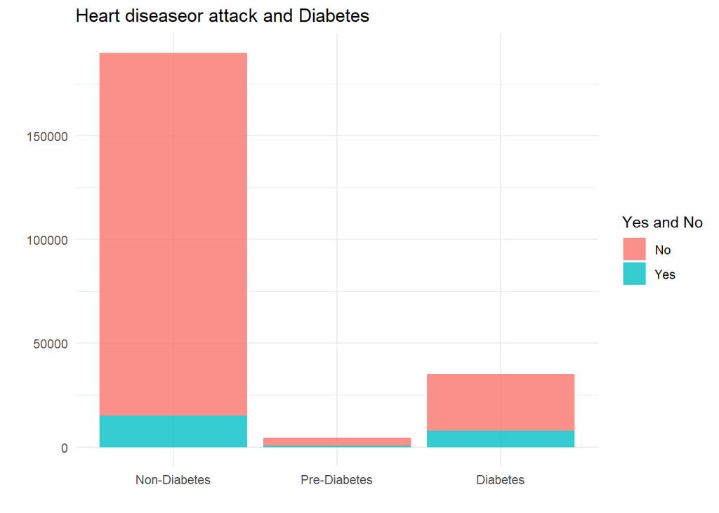

```r
data_diabete|>
  ggplot(aes(x = factor(diabetes_012, levels = c(0, 1, 2),
                       labels = c("Non-Diabetes", "Pre-Diabetes", "Diabetes")),
             fill = factor(ifelse( heart_diseaseor_attack== 1, "Yes", "No")))) +
  geom_bar(stat="count", alpha = 0.8) +
  labs(title = "Heart diseaseor attack and Diabetes",
       x = "",
       y = "",
       fill = "Yes and No") +
  theme_minimal()
```

```r
table(data_diabete$heart_diseaseor_attack,data_diabete$diabetes_012)
```

```
##
##          0      1      2
##   0 174858   3965  27241
##   1  15197    664   7856
```

**Nhận xét**

1. Non (0): Người mắc bệnh tim chiếm khoảng 8%.
2. Pre (1): Người mắc bệnh tim chiếm khoảng 14,34%.
3. Diabete (2): Người mắc bệnh tim chiếm khoảng 22,38%.

=> Theo số liệu ta thấy những người mắc bệnh tim thì có nguy cơ bị tiểu đường cao hơn.

Nhóm đưa ra câu hỏi, **liệu những người cao tuổi và có bệnh nền (bệnh tim) thì có nguy cơ mắc bệnh tiểu đường cao hơn hay không?**

– Kiểm tra câu hỏi

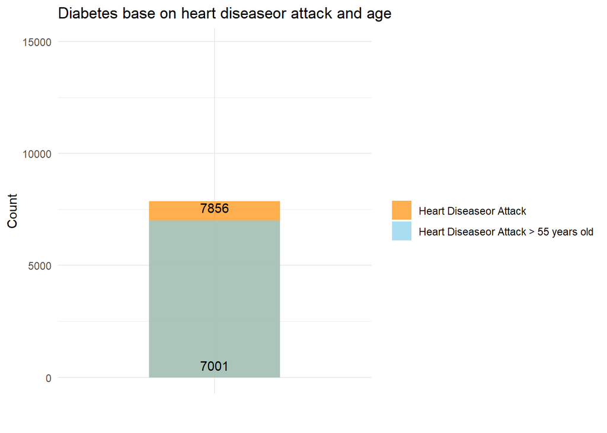

```r
diabetes_heart <- subset(data_diabete, diabetes_012 == 2 & heart_diseaseor_attack == 1)
group_1 <- nrow(diabetes_heart)
diabetes_heart$age <- diabetes_heart$age

group_2 <- nrow(subset(diabetes_heart, as.numeric(diabetes_heart$age) >= 8))
df <- data.frame(
  Subgroup = c("Heart Diseaseor Attack", "Heart Diseaseor Attack > 55 years old"),
  Count = c(group_1, group_2)
)

ggplot(df, aes(x = "", y = Count, fill = Subgroup)) +
  geom_bar(stat = "identity", width = 0.5, position = position_identity(), alpha = 0.7) +
  labs(
    title = "Diabetes base on heart diseaseor attack and age",
    x = "",
    y = "Count",
    fill = ""
  ) +
  theme_minimal() +
  scale_fill_manual(values = c("Heart Diseaseor Attack" = "darkorange", "Heart Diseaseor Attack > 55 years old" = "skyblue")) +
  geom_text(aes(label = Count), position = position_stack(vjust = 0.075))
```

**Nhận xét:** Những người từ 55 tuổi trở lên, mắc bệnh tim và mắc bệnh tiểu đường hơn 89% số người mắc bệnh tim và mắc bệnh tiểu đường.

– `diff_walk` và `diabetes_012`

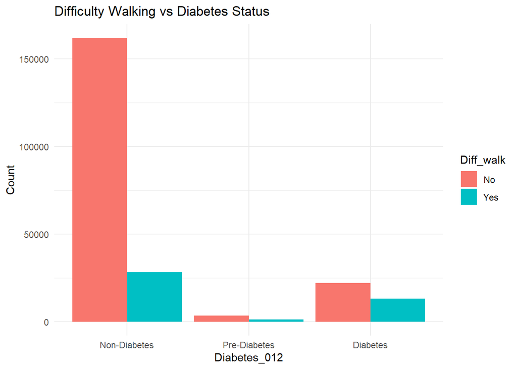

```r
data_diabete |>
  ggplot(aes(x = diabetes_012, fill = factor(diff_walk))) +
  geom_bar(position = "dodge") +
  scale_x_discrete(
    labels = c("Non-Diabetes", "Pre-Diabetes", "Diabetes")
  ) +
  scale_fill_discrete(
    labels = c("No", "Yes")
  ) +
  labs(
    title = "Difficulty Walking vs Diabetes Status",
    x = "Diabetes_012",
    y = "Count",
    fill = "Diff_walk"
  ) +
  theme_minimal()
```

– `gen_health` và `diabetes_012`

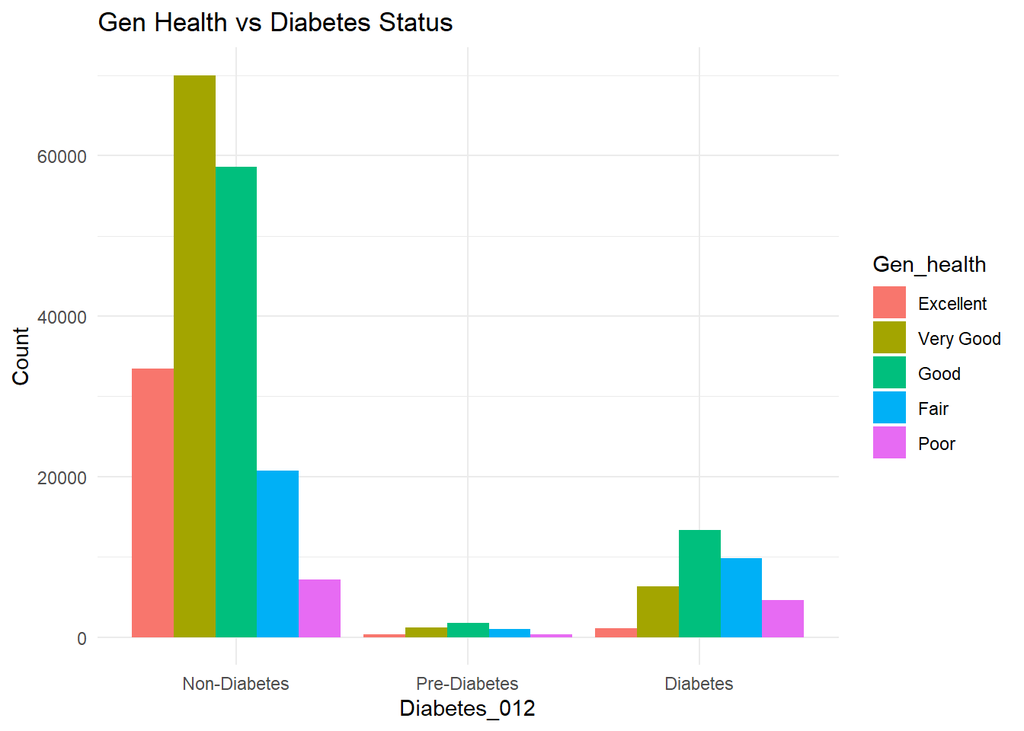

```r
data_diabete |>
  ggplot(aes(x = diabetes_012, fill = gen_hlth)) +
  geom_bar(position = "dodge") +
  scale_x_discrete(
    labels = c("Non-Diabetes", "Pre-Diabetes", "Diabetes")
  ) +
  scale_fill_discrete(
    labels = c("Excellent", "Very Good", "Good", "Fair", "Poor")
  ) +
  labs(
    title = "Gen Health vs Diabetes Status",
    x = "Diabetes_012",
    y = "Count",
    fill = "Gen_health"
  ) +
  theme_minimal()
```

```r
table(data_diabete$gen_hlth,data_diabete$diabetes_012)
```

```
##
##         0     1     2
##   1 33459   313  1135
##   2 70044  1212  6280
##   3 58662  1728 13324
##   4 20740  1025  9781
##   5  7150   351  4577
```

**Nhận xét**

1. Non (0): Người có sức khỏe trung bình/kém chiếm 14,67%.
2. Pre (1): Người có sức khỏe trung bình/kém chiếm 29,73%.
3. Diabetes (2): Người có sức khỏe trung bình/kém chiếm 40,91%.

=> Người bị tiểu đường có điểm đánh giá sức khỏe chung kém hơn các nhóm còn lại.

– `income` và `diabetes_012`

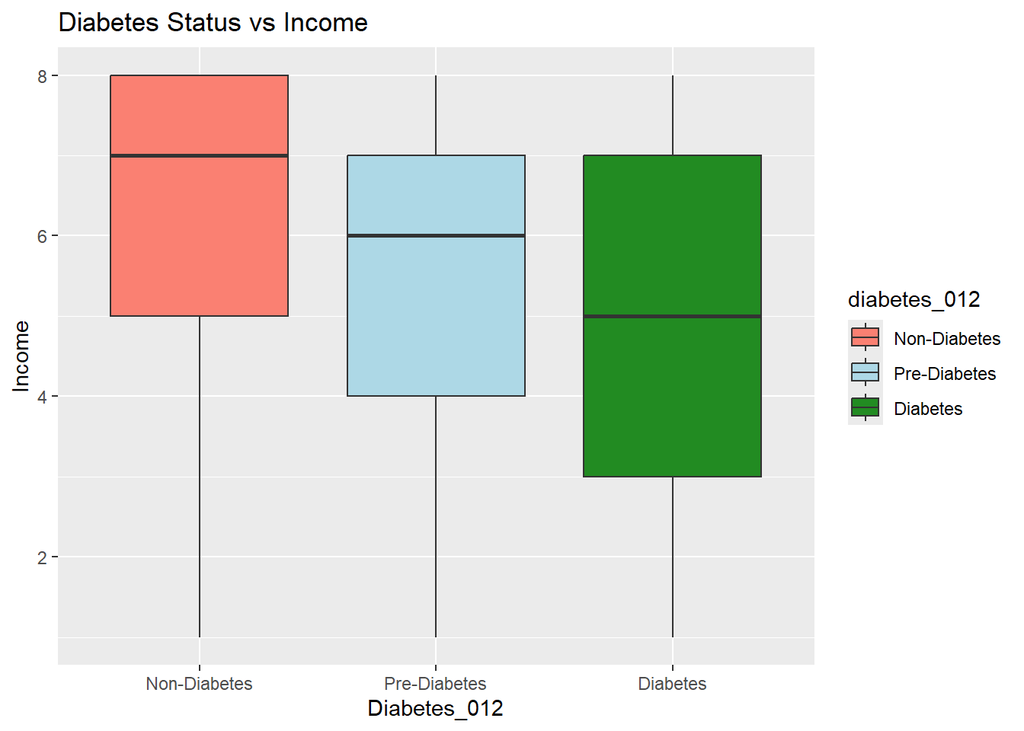

```r
ggplot(data = data_diabete, aes(x = diabetes_012, y = as.numeric(income), fill = diabetes_012)) +
  geom_boxplot() +
  labs(title = "Diabetes Status vs Income", x = "Diabetes_012", y = "Income") +
  scale_fill_manual(values = c("salmon", "lightblue", "forestgreen"), labels = c("Non-Diabetes", "Pre-Diabetes", "Diabetes")) +
  scale_x_discrete(labels = c("0" = "Non-Diabetes", "1" = "Pre-Diabetes", "2" = "Diabetes"))
```

**Nhận xét**: Người có thu nhập càng cao thì càng ít bị tiểu đường hơn. Vì nhóm người này có cơ hội tiếp xúc với điều kiện sống tốt hơn.

– Tương quan giữa biến education và income cao

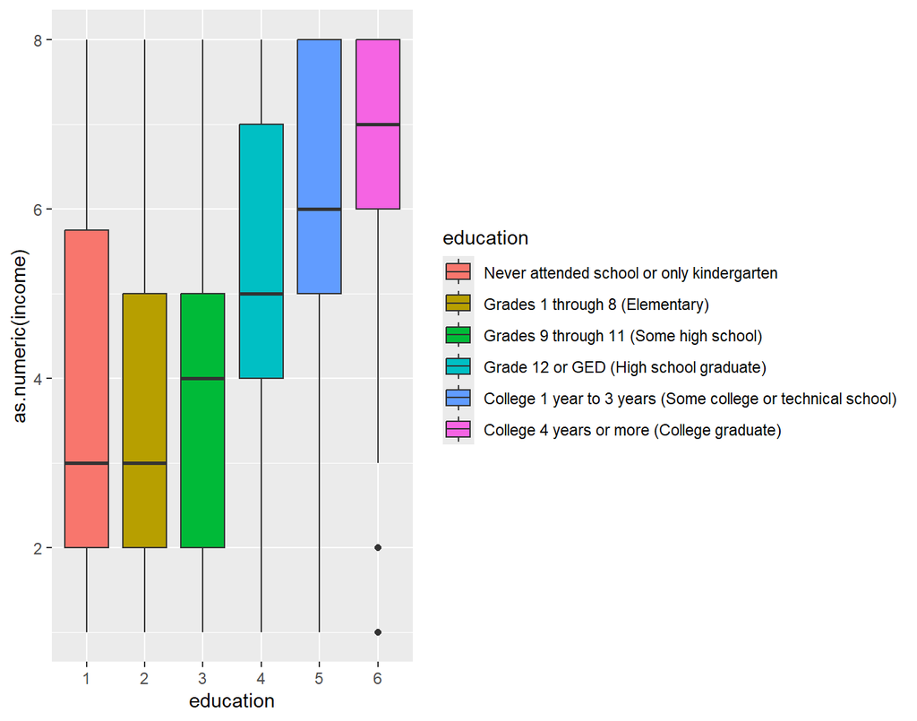

```r
ggplot(data_diabete, aes(x = education, y = as.numeric(income), fill = education)) +
  geom_boxplot() +
  scale_fill_discrete(
    labels = c("Never attended school or only kindergarten", "Grades 1 through 8 (Elementary)", "Grades 9 through 11 (Some high school)", "Grade 12 or GED (High school graduate)", "College 1 year to 3 years (Some college or technical school)", "College 4 years or more (College graduate)"))
```

**Nhận xét**: Người có học vấn càng cao thì có thu nhập càng cao.

- `ment_hlth` vs `phys_hlth`

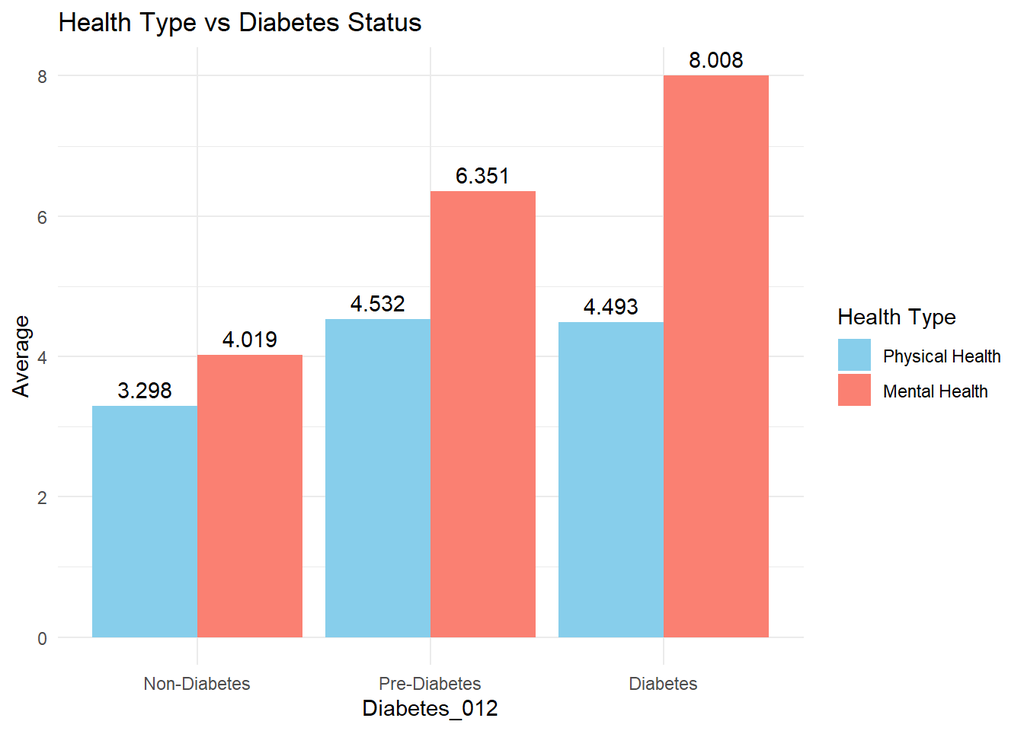

```r
data_summary <- data_diabete |>
  gather(key = "Health_Type", value = "Health_Score", phys_hlth, ment_hlth) |>
  group_by(diabetes_012, Health_Type) %>%
  summarise(tb = round(mean(Health_Score, na.rm = TRUE),3), .groups = "drop") |>
  ungroup()

ggplot(data_summary, aes(x = factor(diabetes_012), y = tb, fill = Health_Type)) +
  geom_bar(stat = "identity", position = "dodge") +
  scale_fill_manual(
    values = c("skyblue", "salmon"),
    labels = c("Physical Health", "Mental Health")
  ) +
  labs(
    title = "Health Type vs Diabetes Status",
    x = "Diabetes_012",
    y = "Average",
    fill = "Health Type"
  ) +
  scale_x_discrete(
    labels = c("Non-Diabetes", "Pre-Diabetes", "Diabetes")
  ) +
  theme_minimal() +
  geom_text(
    aes(label = tb),
    position = position_dodge(width = 0.9),
    vjust = -0.5
  )
```

– Các nhóm biến Lifestyle bao gồm: `phys_activity`, `veggies`, `fruits`

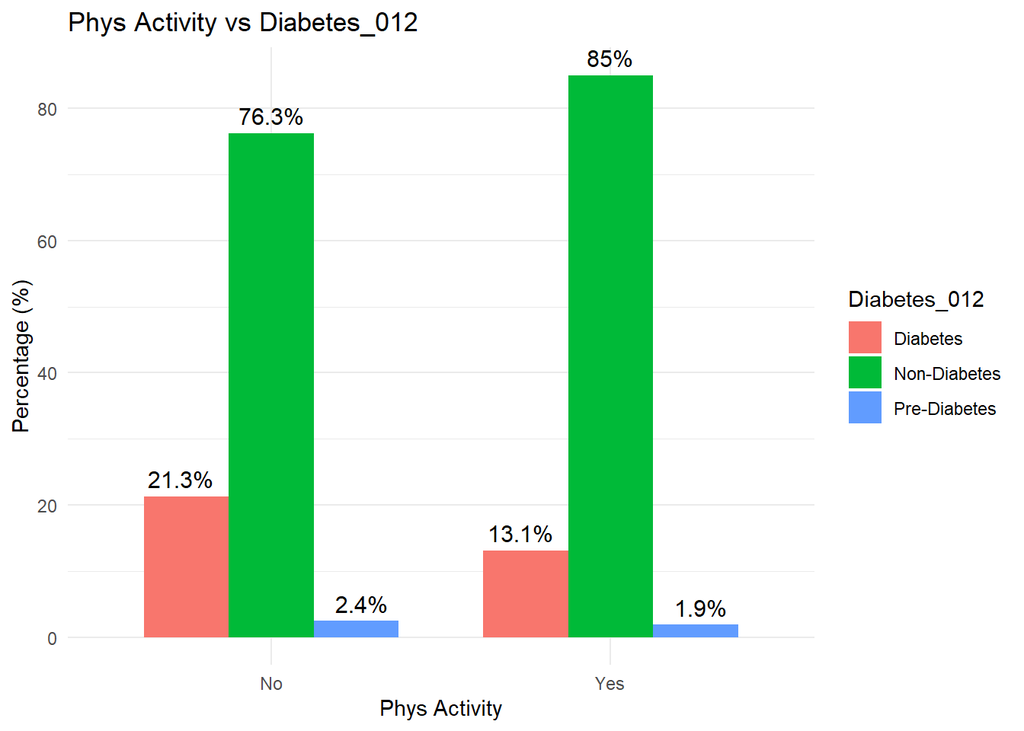

```r
# Phys_activities
gender_dist <- data_diabete |>
group_by(phys_activity, diabetes_012) |>
summarise(Count = n()) |>
mutate(Percentage = Count / sum(Count) * 100)

ggplot(gender_dist,aes(x = factor(ifelse(phys_activity == 1, "Yes", "No")), y = Percentage, fill = ifelse(diabetes_012==2, "Diabetes",ifelse(diabetes_012 == 1, "Pre-Diabetes" ,"Non-Diabetes")))) +
geom_bar(stat = "identity", position = "dodge",width = 0.75) +
geom_text(aes(label = paste0(round(Percentage, 1), "%")),
position = position_dodge(width = 0.8),
vjust = -0.5, size = 4) +
labs(title = "Phys Activity vs Diabetes_012", x = "Phys Activity", y = "Percentage (%)", fill = "Diabetes_012") +
theme_minimal()
```

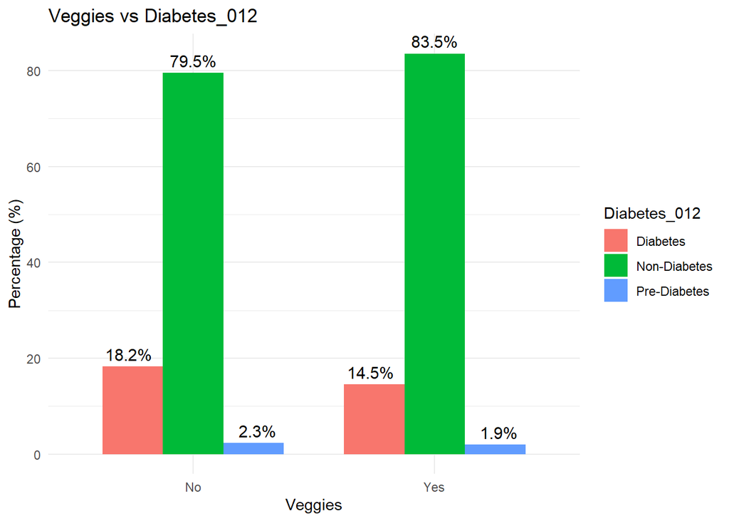

```r
# Veggies
gender_dist <- data_diabete %>%
group_by(veggies, diabetes_012) %>%
summarise(Count = n()) %>%
mutate(Percentage = Count / sum(Count) * 100)

ggplot(gender_dist, aes(x = factor(ifelse(veggies== 1,"Yes", "No")), y = Percentage, fill = factor(ifelse(diabetes_012==2, "Diabetes",ifelse(diabetes_012 == 1, "Pre-Diabetes" ,"Non-Diabetes"))))) +
geom_bar(stat = "identity", position = "dodge",width = 0.75) +
geom_text(aes(label = paste0(round(Percentage, 1), "%")),
position = position_dodge(width = 0.8),
vjust = -0.5, size = 4) +
labs(title = "Veggies vs Diabetes_012", x = "Veggies", y = "Percentage (%)", fill = "Diabetes_012") +
theme_minimal()
```

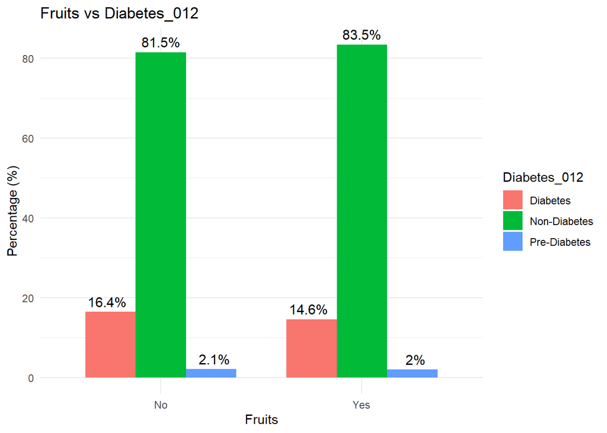

```r
# Fruits
gender_dist <- data_diabete %>%
group_by(fruits, diabetes_012) %>%
summarise(Count = n()) %>%
mutate(Percentage = Count / sum(Count) * 100)

ggplot(gender_dist, aes(x = factor(ifelse(fruits== 1,"Yes", "No")), y = Percentage, fill = factor(ifelse(diabetes_012==2, "Diabetes",ifelse(diabetes_012 == 1, "Pre-Diabetes" ,"Non-Diabetes"))))) +
geom_bar(stat = "identity", position = "dodge",width = 0.75) +
geom_text(aes(label = paste0(round(Percentage, 1), "%")),
position = position_dodge(width = 0.8),
vjust = -0.5, size = 4) +
labs(title = "Fruits vs Diabetes_012", x = "Fruits", y = "Percentage (%)", fill = "Diabetes_012") +
theme_minimal()
```

**Nhận xét**: Những người có lối sống lành mạnh như tham gia hoạt động thể chất, ăn rau xanh và trái cây có thể có tỷ lệ mắc bệnh tiểu đường thấp hơn và tỷ lệ không mắc bệnh cao hơn những người sống thiếu lành mạnh. Điều này cho thấy việc rèn luyện, tham gia hoạt động thể chất, chế độ ăn nhiều rau củ, trái cây chứa nhiều vitamin, giàu chất xơ dường như có ảnh hưởng tích cực đến sức khỏe, giúp giảm nguy cơ mắc bệnh tiểu đường.

– Kiểm tra xem có sự khác biệt đáng kể giữa hai biến `Pre-diabete` và `Diabete` thông qua một số biến đặc trưng

```r
select_12 <- data_diabete |> filter(!diabetes_012 == 0)
table(select_12['diabetes_012'])
```

```
## diabetes_012
##     0     1     2
##     0  4629 35097
```

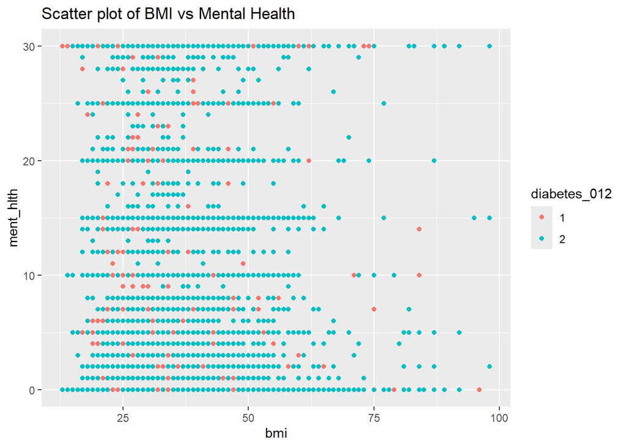

```r
ggplot(select_12, aes(x = bmi, y = ment_hlth, color = diabetes_012)) +
  geom_point() +
  labs(title = "Scatter plot of BMI vs Mental Health")
```

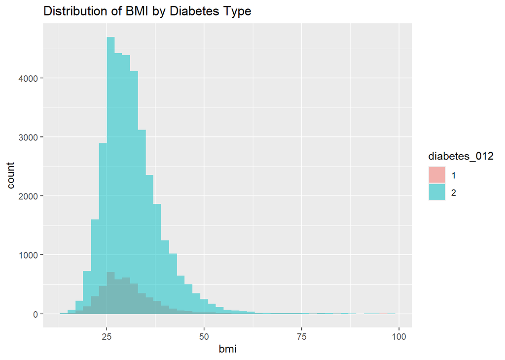

```r
# Histogram of bmi
ggplot(select_12, aes(x = bmi, fill = diabetes_012)) +
  geom_histogram(binwidth = 2, alpha = 0.5, position = "identity") +
  labs(title = "Distribution of BMI by Diabetes Type")
```

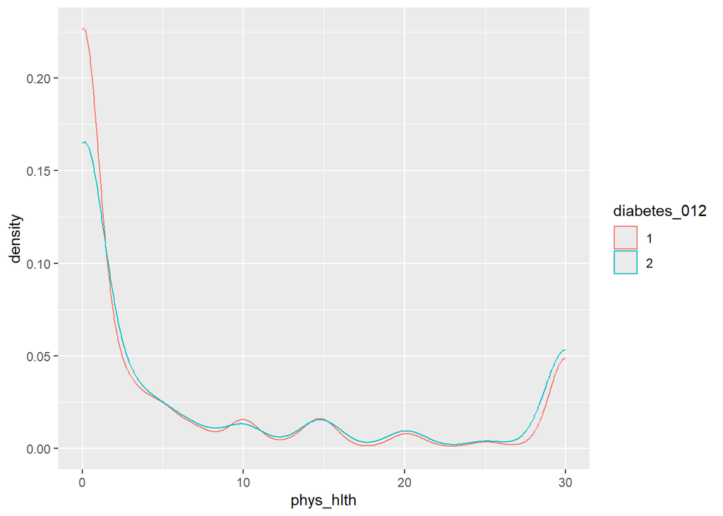

```r
# Density plot of physical health (phys_hlth)
ggplot(select_12, aes(x = phys_hlth, color = diabetes_012)) +
  geom_density()
```

*Nhận xét:** Thông qua một vài biến đặc trưng thì ta thấy không có sự khác biệt đáng kể giữa hai biến `Pre-diabete` và `Diabete`.

# II. A/B Testing

```r
# Lấy ngẫu nhiên 10% dữ liệu đã cho
set.seed(123)
sample_data <- data_diabete |> sample_frac(0.1)  # Lấy 10% dữ liệu
```

- **Kiểm tra các biến định tính giả thuyết đặt ra có chính xác hay không**

```r
set.seed(123)

resampling_method <- function(data, x, y, R) {
  contingency_table <- table(data[[x]], data[[y]])
  ri <- rowSums(contingency_table)  # Tổng các quan sát theo dòng
  cj <- colSums(contingency_table)  # Tổng các quan sát theo cột
  N <- sum(contingency_table)       # Tổng số lượng quan sát

  Eij <- outer(ri, cj, FUN = "*") / N
  observed_w <- sum((contingency_table - Eij)^2 / Eij)
  w_star <- numeric(R)
  for (r in 1:R) {
    sample_i <- rep(1:length(ri), ri)
    sample_j <- sample(sample_i, size = length(sample_i), replace = TRUE)
    new_contingency_table <- table(sample_i, sample_j)
    E_star_ij <- outer(rowSums(new_contingency_table), colSums(new_contingency_table), FUN = "*") / N
    w_star[r] <- sum((new_contingency_table - E_star_ij)^2 / E_star_ij)
  }

  p_value <- mean(w_star > observed_w)
  return(p_value)
}
```

**Kiểm tra các biến định tính có độc lập với biến mục tiêu không**

```r
data_diabete_var <- sample_data |>
select(-c("bmi","ment_hlth","phys_hlth"))

correlation_test <- function(df, target_var) {
results <- data.frame(
Variable = character(),
P_Value = numeric(),
stringsAsFactors = FALSE
)


for (col_name in colnames(df)) {
if (col_name == target_var) next

if (is.factor(df[[col_name]]) || is.character(df[[col_name]])) {
freq_table <- table(df[[target_var]], df[[col_name]])

test <- resampling_method(data_diabete_var,col_name,target_var,100)

results <- rbind(results, data.frame(
Variable = col_name,
p_value = test
))
}
}
results <- results[order(results$p_value), ]

# Trả về bảng kết quả
return(results)
}
```

```r
# Gọi hàm với dataframe data_diabete và biến mục tiêu diabetes_012
correlation_test(data_diabete_var, "diabetes_012")
```

```
##                  Variable p_value
## 1                 high_bp       0
## 2               high_chol       0
## 3              chol_check       0
## 4                  smoker       0
## 5                  stroke       0
## 6  heart_diseaseor_attack       0
## 7           phys_activity       0
## 8                  fruits       0
## 9                 veggies       0
## 10    hvy_alcohol_consump       0
## 11         any_healthcare       0
## 12          no_docbc_cost       0
## 13               gen_hlth       0
## 14              diff_walk       0
## 15                    sex       0
## 16                    age       0
## 17              education       0
## 18                 income       0
```

**Nhận xét**: p_value của các biến định tính gần như bằng không. Bác bỏ H0, tức là các biến đều có sự phụ thuộc vào biến mục tiêu.

- **Kiểm định ANOVA**

– `bmi` của 3 nhóm 0, 1, 2 có tương đồng nhau

```r
anova_bmi <- aovp(formula = bmi ~ diabetes_012, data = sample_data , perm ="Prob")  # Giảm xuống 1000 lần hoán vị
```

```
## [1] "Settings:  unique SS "
```

```r
summary(anova_bmi)
```

```
## Component 1 :
##                 Df R Sum Sq R Mean Sq Iter  Pr(Prob)
## diabetes_012     2    48264   24131.9 5000 < 2.2e-16 ***
## Residuals    22975  1058579      46.1
## ---
## Signif. codes:  0 '***' 0.001 '**' 0.01 '*' 0.05 '.' 0.1 ' ' 1
```

**Nhận xét:** p_value = 2.2e-16 rất nhỏ.

– `ment_hlth` của 3 nhóm 0, 1, 2 có tương đồng nhau

```r
anova_ment <- aovp(formula = ment_hlth ~ diabetes_012, data = sample_data , perm ="Prob")  # Giảm xuống 1000 lần hoán vị
```

```
## [1] "Settings:  unique SS "
```

```r
summary(anova_ment)
```

```
## Component 1 :
##                 Df R Sum Sq R Mean Sq Iter  Pr(Prob)
## diabetes_012     2     4941    2470.4 5000 < 2.2e-16 ***
## Residuals    22975  1369403      59.6
## ---
## Signif. codes:  0 '***' 0.001 '**' 0.01 '*' 0.05 '.' 0.1 ' ' 1
```

**Nhận xét:** p_value = 2.2e-16 rất nhỏ.

– `phys_hlth` của 3 nhóm 0, 1, 2 có tương đồng nhau

```r
anova_phys <- aovp(formula = phys_hlth ~ diabetes_012, data = sample_data , perm ="Prob")  # Giảm xuống 1000 lần hoán vị
```

```
## [1] "Settings:  unique SS "
```

```r
summary(anova_phys)
```

```
## Component 1 :
##                 Df R Sum Sq R Mean Sq Iter  Pr(Prob)
## diabetes_012     2    49154   24577.0 5000 < 2.2e-16 ***
## Residuals    22975  1846881      80.4
## ---
## Signif. codes:  0 '***' 0.001 '**' 0.01 '*' 0.05 '.' 0.1 ' ' 1
```

**Nhận xét:** p_value = 2.2e-16 rất nhỏ.

# III. Classification Model

## 1. Multi-Classification for Non-Pre-Diabete Prediction

### Correlation

Đổi biến `diabetes_012` thành `diabetes_type`

```r
data <- data |> rename(diabetes_type = diabetes_012)
data_diabete <- data
corr <- cor(data_diabete[,-1], data_diabete[,1])
corr
```

```
##                        diabetes_type
## high_bp                   0.27159642
## high_chol                 0.20908491
## chol_check                0.06754648
## bmi                       0.22437947
## smoker                    0.06291410
## stroke                    0.10717867
## heart_diseaseor_attack    0.18027169
## phys_activity            -0.12194717
## fruits                   -0.04219163
## veggies                  -0.05897160
## hvy_alcohol_consump      -0.05788191
## any_healthcare            0.01541038
## no_docbc_cost             0.03543569
## gen_hlth                  0.30258662
## ment_hlth                 0.07350677
## phys_hlth                 0.17628674
## diff_walk                 0.22423912
## sex                       0.03104016
## age                       0.18502579
## education                -0.13051692
## income                   -0.17148304
```

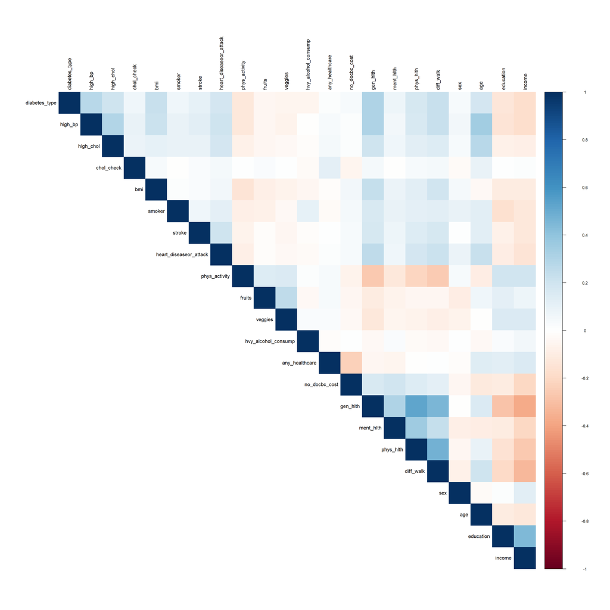

```r
corrplot(cor(data_diabete), method = "color", type = "upper", tl.col = "black")
```

Top 10 biến có tương quan cao nhất với biến mục tiêu `diabetes_type`:

```r
top_features <- names(sort(abs(corr[,1]), decreasing = TRUE))[1:10]
top_features
```

```
##  [1] "gen_hlth"               "high_bp"                "bmi"
##  [4] "diff_walk"              "high_chol"              "age"
##  [7] "heart_diseaseor_attack" "phys_hlth"              "income"
## [10] "education"
```

### Preprocessing for modeling

Chuyển đổi kiểu dữ liệu của `diabetes_type` thành factor:

```r
data_diabete <- data_diabete |> mutate(diabetes_type = factor(diabetes_type, levels = c(0,1,2),
                                                              labels = c("Non-diabete",
                                                                         "Pre-diabete",
                                                                         "Diabete")))
```

Chuyển đổi kiểu dữ liệu của top 10 biến có tương quan cao nhất với biến mục tiêu into factor:

```r
data_diabete <- data_diabete |> mutate(gen_hlth = factor(gen_hlth, levels = c(1,2,3,4,5),
                                                         labels = c("Excellent",
                                                                    "Very good",
                                                                    "Good",
                                                                    "Fair",
                                                                    "Poor")))
data_diabete <- data_diabete |> mutate(high_bp = factor(high_bp, levels = c(0,1), labels = c("No", "Yes")))
data_diabete <- data_diabete |> mutate(high_chol = factor(high_chol, levels = c(0,1), labels = c("No", "Yes")))
data_diabete <- data_diabete |> mutate(diff_walk = factor(diff_walk, levels = c(0,1), labels = c("No", "Yes")))
data_diabete <- data_diabete |> mutate(heart_diseaseor_attack = factor(heart_diseaseor_attack, levels = c(0,1), labels = c("No", "Yes")))
data_diabete <- data_diabete |> mutate(age = factor(age, levels = c(1,2,3,4,5,6,7,8,9,10,11,12,13),
                                                    labels = c("18-24",
                                                               "24-29",
                                                               "30-34",
                                                               "35-39",
                                                               "40-44",
                                                               "45-49",
                                                               "50-54",
                                                               "55-59",
                                                               "60-64",
                                                               "65-69",
                                                               "70-74",
                                                               "75-79",
                                                               "80-older")))
data_diabete <- data_diabete |> mutate(income = factor(income, levels = c(1,2,3,4,5,6,7,8),
                                                       labels = c("Under $10.000",
                                                                  "$10.000 - $15.000",
                                                                  "$15.000 - $20.000",
                                                                  "$20.000 - $25.000",
                                                                  "$25.000 - $35.000",
                                                                  "$35.000 - $50.000",
                                                                  "$50.000 - $75.000",
                                                                  "Over $75.000")))
data_diabete <- data_diabete |> mutate(education = factor(education, levels = c(1,2,3,4,5,6),
                                                          labels = c("Under or Kindergarten",
                                                                     "Elementary",
                                                                     "Secondary and Some High School",
                                                                     "High School graduate",
                                                                     "College",
                                                                     "College graduate")))
```

Chọn dữ liệu để xây dựng mô hình:

```r
selected_data <- data_diabete |> dplyr::select(top_features, diabetes_type)
glimpse(selected_data)
```

```
## Rows: 253,680
## Columns: 11
## $ gen_hlth               <fct> Poor, Good, Poor, Very good, Very good, Very go…
## $ high_bp                <fct> Yes, No, Yes, Yes, Yes, Yes, Yes, Yes, Yes, No,…
## $ bmi                    <dbl> 40, 25, 28, 27, 24, 25, 30, 25, 30, 24, 25, 34,…
## $ diff_walk              <fct> Yes, No, Yes, No, No, No, No, Yes, Yes, No, No,…
## $ high_chol              <fct> Yes, No, Yes, No, Yes, Yes, No, Yes, Yes, No, N…
## $ age                    <fct> 60-64, 50-54, 60-64, 70-74, 70-74, 65-69, 60-64…
## $ heart_diseaseor_attack <fct> No, No, No, No, No, No, No, No, Yes, No, No, No…
## $ phys_hlth              <dbl> 15, 0, 30, 0, 0, 2, 14, 0, 30, 0, 0, 30, 15, 0,…
## $ income                 <fct> $15.000 - $20.000, Under $10.000, Over $75.000,…
## $ education              <fct> High School graduate, College graduate, High Sc…
## $ diabetes_type          <fct> Non-diabete, Non-diabete, Non-diabete, Non-diab…
```

```r
table(selected_data['diabetes_type'])
```

```
## diabetes_type
## Non-diabete Pre-diabete     Diabete
##      213703        4631       35346
```

Train-Test Split:

```r
set.seed(123)

min_count <- min(table(selected_data$diabetes_type))
test_size <- round(0.2 * min_count)
TestSet <- selected_data |>
  group_by(diabetes_type) |>
  slice_sample(n = test_size) |>
  ungroup()

TrainSet <- selected_data |> filter(!row_number() %in% row_number(TestSet))
```

```r
dim(TrainSet)
```

```
## [1] 250902     11
```

```r
print(table(TrainSet["diabetes_type"]))
```

```
## diabetes_type
## Non-diabete Pre-diabete     Diabete
##      211551        4583       34768
```

```r
dim(TestSet)
```

```
## [1] 2778   11
```

```r
print(table(TestSet["diabetes_type"]))
```

```
## diabetes_type
## Non-diabete Pre-diabete     Diabete
##         926         926         926
```

### Build Model

#### Experiment 1: Multinominal Logistic Regression

##### With Original Data

```r
library(nnet)
out_md_mlogit <- multinom(diabetes_type ~ ., data = TrainSet, maxit = 1000)
pred_mlogit_test <- predict(out_md_mlogit, newdata = TestSet, type = "class")
eval_mlogit_test <- confusionMatrix(data = pred_mlogit_test, reference = TestSet$diabetes_type)
eval_mlogit_test
```

```
## Confusion Matrix and Statistics
##
##              Reference
## Prediction    Non-diabete Pre-diabete Diabete
##   Non-diabete         902         843     764
##   Pre-diabete           0           0       0
##   Diabete              24          83     162
##
## Overall Statistics
##
##                Accuracy : 0.383
##                  95% CI : (0.3649, 0.4014)
##     No Information Rate : 0.3333
##     P-Value [Acc > NIR] : 2.195e-08
##
##                   Kappa : 0.0745
##
##  Mcnemar's Test P-Value : < 2.2e-16
##
## Statistics by Class:
##
##                      Class: Non-diabete Class: Pre-diabete Class: Diabete
## Sensitivity                      0.9741             0.0000        0.17495
## Specificity                      0.1323             1.0000        0.94222
## Pos Pred Value                   0.3595                NaN        0.60223
## Neg Pred Value                   0.9108             0.6667        0.69550
## Prevalence                       0.3333             0.3333        0.33333
## Detection Rate                   0.3247             0.0000        0.05832
## Detection Prevalence             0.9032             0.0000        0.09683
## Balanced Accuracy                0.5532             0.5000        0.55859
```

```r
eval_multi_class <- function(x) {
  cc <- sum(diag(x))
  sc <- sum(x)
  pp <- colSums(x)
  tt <- rowSums(x)
  ##
  prec <- diag(x)/colSums(x)
  recall <- diag(x)/rowSums(x)
  macro_prec <- mean(prec)
  macro_recall <- mean(recall)
  macro_f1 <- 2 * macro_prec * macro_recall/(1/macro_prec + 1/macro_recall)
  acc <- cc/sc
  kap <- (cc * sc - sum(pp * tt))/(sc^2 - sum(pp * tt))
  return(list(Precision = prec, Recall = recall, Accuracy = acc, Kappa = kap,
  Macro_F1 = macro_f1))
}
eval_multi_class(table(TestSet$diabetes_type, pred_mlogit_test))
```

```
## $Precision
## Non-diabete Pre-diabete     Diabete
##   0.3595058         NaN   0.6022305
##
## $Recall
## Non-diabete Pre-diabete     Diabete
##   0.9740821   0.0000000   0.1749460
##
## $Accuracy
## [1] 0.3830094
##
## $Kappa
## [1] 0.07451404
##
## $Macro_F1
## [1] NaN
```

**Nhận xét:** Vì có sự mất cân bằng dữ liệu nên làm cho mô hình không thể dự đoán được các lớp tiền tiểu đường, dẫn đến các chỉ số mô hình bị rỗng.

Kiểm tra số lượng dữ liệu của từng nhãn:

```r
table(data_diabete["diabetes_type"])
```

```
## diabetes_type
## Non-diabete Pre-diabete     Diabete
##      213703        4631       35346
```

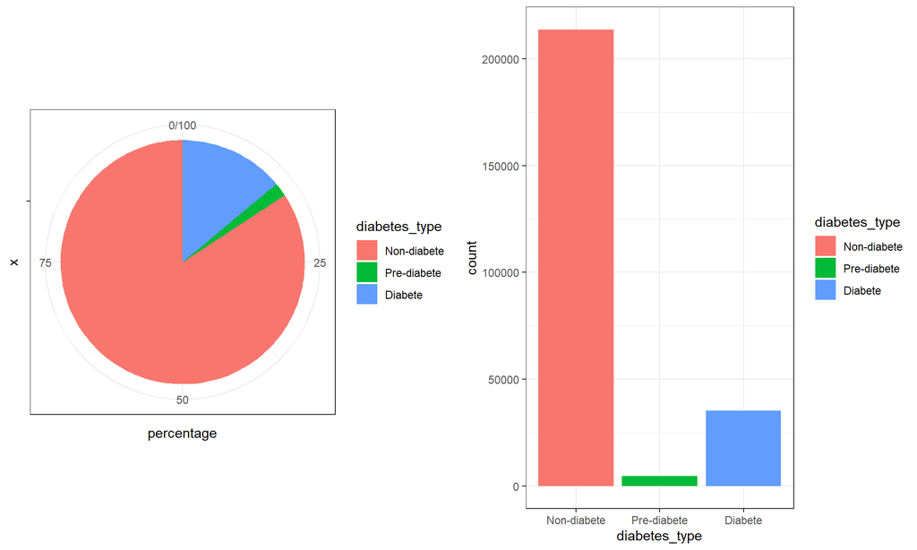

```r
pie_data <- data_diabete |>
  count(diabetes_type) |>
  mutate(percentage = n/sum(n)*100)
pie_db_type <- ggplot(pie_data, aes(x="", y=percentage, fill=diabetes_type)) +
  geom_bar(stat="identity", width=1) +
  coord_polar("y", start=0) +
  theme_bw()

bar_db_type <- ggplot(data_diabete, aes(x=diabetes_type, fill=diabetes_type)) +
  geom_bar() +
  theme_bw()

grid.arrange(pie_db_type, bar_db_type, ncol = 2)
```

##### Experiment 1.1: With Random Under Sampling:

```r
under_sampling <- function(data, name_class){
  new_data <- data
  class_fact <- data[, name_class]
  data_split <- split(data, class_fact)
  n_class <- sapply(data_split, FUN = nrow)
  n_minor <- min(n_class)
  n_major <- max(n_class)
  id_major_class <- which.max(n_class)
  id_minor_class <- which.min(n_class)
  rs_data <- lapply(data_split, function(class_data){
    class_data[sample(1:nrow(class_data), size = n_minor, replace = FALSE),]
  })
  new_data <- do.call(rbind,rs_data)
  return(new_data)
}
```

```r
TrainSet_us <- under_sampling(TrainSet,"diabetes_type")
table(TrainSet_us["diabetes_type"])
```

```
## diabetes_type
## Non-diabete Pre-diabete     Diabete
##        4583        4583        4583
```

```r
out_md_mlogit_us <- multinom(diabetes_type ~ ., data = TrainSet_us, maxit = 1000)
pred_us <- predict(out_md_mlogit_us, newdata = TestSet, type = "class")
eval_us <- confusionMatrix(data = pred_us, reference = TestSet$diabetes_type)
eval_us
```

```
## Confusion Matrix and Statistics
##
##              Reference
## Prediction    Non-diabete Pre-diabete Diabete
##   Non-diabete         576         249     144
##   Pre-diabete         173         292     252
##   Diabete             177         385     530
##
## Overall Statistics
##
##                Accuracy : 0.5032
##                  95% CI : (0.4845, 0.522)
##     No Information Rate : 0.3333
##     P-Value [Acc > NIR] : < 2.2e-16
##
##                   Kappa : 0.2549
##
##  Mcnemar's Test P-Value : 9.962e-10
##
## Statistics by Class:
##
##                      Class: Non-diabete Class: Pre-diabete Class: Diabete
## Sensitivity                      0.6220             0.3153         0.5724
## Specificity                      0.7878             0.7705         0.6965
## Pos Pred Value                   0.5944             0.4073         0.4853
## Neg Pred Value                   0.8065             0.6924         0.7651
## Prevalence                       0.3333             0.3333         0.3333
## Detection Rate                   0.2073             0.1051         0.1908
## Detection Prevalence             0.3488             0.2581         0.3931
## Balanced Accuracy                0.7049             0.5429         0.6344
```

```r
eval_multi_class(table(TestSet$diabetes_type, pred_us))
```

```
## $Precision
## Non-diabete Pre-diabete     Diabete
##   0.5944272   0.4072524   0.4853480
##
## $Recall
## Non-diabete Pre-diabete     Diabete
##   0.6220302   0.3153348   0.5723542
##
## $Accuracy
## [1] 0.5032397
##
## $Kappa
## [1] 0.2548596
##
## $Macro_F1
## [1] 0.1245795
```

##### Experiment 1.2: With Random Over Sampling:

```r
over_sampling <- function(data, name_class){
  new_data <- data
  class_fact <- data[, name_class]
  data_split <- split(data, class_fact)
  n_class <- sapply(data_split, FUN = nrow)
  n_minor <- min(n_class)
  n_major <- max(n_class)
  id_major_class <- which.max(n_class)
  id_minor_class <- which.min(n_class)
  rs_data <- lapply(data_split, function(class_data){
    n <- nrow(class_data)
    if (n < n_major) {
      class_data[sample(1:n, size = n_major, replace = TRUE), ]
    } else {
      class_data
    }
  })
  new_data <- do.call(rbind,rs_data)
  return(new_data)
}
```

```r
TrainSet_os <- over_sampling(TrainSet,"diabetes_type")
table(TrainSet_os["diabetes_type"])
```

```
## diabetes_type
## Non-diabete Pre-diabete     Diabete
##      211551      211551      211551
```

```r
out_md_mlogit_os <- multinom(diabetes_type ~ ., data = TrainSet_os, maxit = 1000)
pred_os <- predict(out_md_mlogit_os, newdata = TestSet, type = "class")
eval_os <- confusionMatrix(data = pred_os, reference = TestSet$diabetes_type)
eval_os
```

```
## Confusion Matrix and Statistics
##
##              Reference
## Prediction    Non-diabete Pre-diabete Diabete
##   Non-diabete         583         251     143
##   Pre-diabete         178         294     231
##   Diabete             165         381     552
##
## Overall Statistics
##
##                Accuracy : 0.5144
##                  95% CI : (0.4956, 0.5331)
##     No Information Rate : 0.3333
##     P-Value [Acc > NIR] : < 2.2e-16
##
##                   Kappa : 0.2716
##
##  Mcnemar's Test P-Value : 5.509e-11
##
## Statistics by Class:
##
##                      Class: Non-diabete Class: Pre-diabete Class: Diabete
## Sensitivity                      0.6296             0.3175         0.5961
## Specificity                      0.7873             0.7792         0.7052
## Pos Pred Value                   0.5967             0.4182         0.5027
## Neg Pred Value                   0.8096             0.6954         0.7774
## Prevalence                       0.3333             0.3333         0.3333
## Detection Rate                   0.2099             0.1058         0.1987
## Detection Prevalence             0.3517             0.2531         0.3952
## Balanced Accuracy                0.7084             0.5483         0.6506
```

```r
eval_multi_class(table(TestSet$diabetes_type, pred_os))
```

```
## $Precision
## Non-diabete Pre-diabete     Diabete
##   0.5967247   0.4182077   0.5027322
##
## $Recall
## Non-diabete Pre-diabete     Diabete
##   0.6295896   0.3174946   0.5961123
##
## $Accuracy
## [1] 0.5143988
##
## $Kappa
## [1] 0.2715983
##
## $Macro_F1
## [1] 0.1327445
```

##### Experiment 1.3: With SMOTE:

```r
TrainSet_smote <- smotenc(TrainSet, var = "diabetes_type",
                          k = 10, over_ratio = 1)
table(TrainSet_smote["diabetes_type"])
```

```
## diabetes_type
## Non-diabete Pre-diabete     Diabete
##      211551      211551      211551
```

```r
out_md_mlogit_smote <- multinom(diabetes_type ~ ., data = TrainSet_smote, maxit = 1000)
pred_smote <- predict(out_md_mlogit_smote, newdata = TestSet, type = "class")
eval_smote <- confusionMatrix(data = pred_smote, reference = TestSet$diabetes_type)
eval_smote
```

```
## Confusion Matrix and Statistics
##
##              Reference
## Prediction    Non-diabete Pre-diabete Diabete
##   Non-diabete         569         236     144
##   Pre-diabete         210         331     243
##   Diabete             147         359     539
##
## Overall Statistics
##
##                Accuracy : 0.518
##                  95% CI : (0.4992, 0.5367)
##     No Information Rate : 0.3333
##     P-Value [Acc > NIR] : < 2.2e-16
##
##                   Kappa : 0.277
##
##  Mcnemar's Test P-Value : 2.623e-05
##
## Statistics by Class:
##
##                      Class: Non-diabete Class: Pre-diabete Class: Diabete
## Sensitivity                      0.6145             0.3575         0.5821
## Specificity                      0.7948             0.7554         0.7268
## Pos Pred Value                   0.5996             0.4222         0.5158
## Neg Pred Value                   0.8048             0.7016         0.7767
## Prevalence                       0.3333             0.3333         0.3333
## Detection Rate                   0.2048             0.1192         0.1940
## Detection Prevalence             0.3416             0.2822         0.3762
## Balanced Accuracy                0.7046             0.5564         0.6544
```

```r
eval_multi_class(table(TestSet$diabetes_type, pred_smote))
```

```
## $Precision
## Non-diabete Pre-diabete     Diabete
##   0.5995785   0.4221939   0.5157895
##
## $Recall
## Non-diabete Pre-diabete     Diabete
##   0.6144708   0.3574514   0.5820734
##
## $Accuracy
## [1] 0.5179986
##
## $Kappa
## [1] 0.2769978
##
## $Macro_F1
## [1] 0.1367898
```

##### Experiment 1.4: Class Weight

```r
class_counts <- table(TrainSet$diabetes_type)
class_weights <- nrow(TrainSet) / class_counts
class_weights
```

```
##
## Non-diabete Pre-diabete     Diabete
##    1.186012   54.746236    7.216463
```

```r
weights <- as.vector(class_weights[TrainSet$diabetes_type])
length(weights)
```

```
## [1] 250902
```

```r
out_md_mlogit_w <- multinom(diabetes_type ~ ., data = TrainSet, weights = weights)
pred_w <- predict(out_md_mlogit_w, newdata = TestSet, type = "class")
eval_w <- confusionMatrix(data = pred_w, reference = TestSet$diabetes_type)
eval_w
```

```
## Confusion Matrix and Statistics
##
##              Reference
## Prediction    Non-diabete Pre-diabete Diabete
##   Non-diabete         582         248     145
##   Pre-diabete         180         298     229
##   Diabete             164         380     552
##
## Overall Statistics
##
##                Accuracy : 0.5155
##                  95% CI : (0.4967, 0.5342)
##     No Information Rate : 0.3333
##     P-Value [Acc > NIR] : < 2.2e-16
##
##                   Kappa : 0.2732
##
##  Mcnemar's Test P-Value : 1.066e-10
##
## Statistics by Class:
##
##                      Class: Non-diabete Class: Pre-diabete Class: Diabete
## Sensitivity                      0.6285             0.3218         0.5961
## Specificity                      0.7878             0.7792         0.7063
## Pos Pred Value                   0.5969             0.4215         0.5036
## Neg Pred Value                   0.8092             0.6968         0.7776
## Prevalence                       0.3333             0.3333         0.3333
## Detection Rate                   0.2095             0.1073         0.1987
## Detection Prevalence             0.3510             0.2545         0.3945
## Balanced Accuracy                0.7082             0.5505         0.6512
```

```r
eval_multi_class(table(TestSet$diabetes_type, pred_w))
```

```
## $Precision
## Non-diabete Pre-diabete     Diabete
##   0.5969231   0.4214993   0.5036496
##
## $Recall
## Non-diabete Pre-diabete     Diabete
##   0.6285097   0.3218143   0.5961123
##
## $Accuracy
## [1] 0.5154788
##
## $Kappa
## [1] 0.2732181
##
## $Macro_F1
## [1] 0.1337437
```

##### Experiment 1.5: Combine UnderSampling with SMOTE

UnderSampling về trung bình số lượng 3 nhóm trong tập dữ liệu, sau đó sử dụng SMOTE để data generation các nhóm có cỡ mẫu thấp hơn về mức trung bình.

```r
# Under Sampling
new_data <- TrainSet
class_fact <- TrainSet[, "diabetes_type"]
data_split <- split(TrainSet, class_fact)
n_class <- sapply(data_split, FUN = nrow)
n_major <- max(n_class)
id_major_class <- which.max(n_class)
id_major <- sample(1:n_major, size = mean(nrow(TrainSet)/3), replace = FALSE)
new_data_major <- data_split[[id_major_class]][id_major, ]
new_data <- rbind(data_split[[2]], new_data_major, data_split[[3]])
# SMOTE
TrainSet_cmb <- smotenc(new_data, var = "diabetes_type",
                        k = 5, over_ratio = 1)
table(TrainSet_cmb["diabetes_type"])
```

```
## diabetes_type
## Non-diabete Pre-diabete     Diabete
##       83634       83634       83634
```

```r
out_md_mlogit_cmb <- multinom(diabetes_type ~ ., data = TrainSet_cmb, maxit = 1000)
pred_cmb <- predict(out_md_mlogit_cmb, newdata = TestSet, type = "class")
eval_cmb <- confusionMatrix(data = pred_cmb, reference = TestSet$diabetes_type)
eval_cmb
```

```
## Confusion Matrix and Statistics
##
##              Reference
## Prediction    Non-diabete Pre-diabete Diabete
##   Non-diabete         562         238     143
##   Pre-diabete         223         332     247
##   Diabete             141         356     536
##
## Overall Statistics
##
##                Accuracy : 0.5148
##                  95% CI : (0.496, 0.5335)
##     No Information Rate : 0.3333
##     P-Value [Acc > NIR] : < 2.2e-16
##
##                   Kappa : 0.2721
##
##  Mcnemar's Test P-Value : 0.0001539
##
## Statistics by Class:
##
##                      Class: Non-diabete Class: Pre-diabete Class: Diabete
## Sensitivity                      0.6069             0.3585         0.5788
## Specificity                      0.7943             0.7462         0.7316
## Pos Pred Value                   0.5960             0.4140         0.5189
## Neg Pred Value                   0.8016             0.6994         0.7765
## Prevalence                       0.3333             0.3333         0.3333
## Detection Rate                   0.2023             0.1195         0.1929
## Detection Prevalence             0.3395             0.2887         0.3719
## Balanced Accuracy                0.7006             0.5524         0.6552
```

```r
eval_multi_class(table(TestSet$diabetes_type, pred_cmb))
```

```
## $Precision
## Non-diabete Pre-diabete     Diabete
##   0.5959703   0.4139651   0.5188771
##
## $Recall
## Non-diabete Pre-diabete     Diabete
##   0.6069114   0.3585313   0.5788337
##
## $Accuracy
## [1] 0.5147588
##
## $Kappa
## [1] 0.2721382
##
## $Macro_F1
## [1] 0.1343537
```

##### Experiment 1.6: Combine UnderSampling with OverSampling

```r
TrainSet_cmb_os <- over_sampling(new_data, "diabetes_type")
table(TrainSet_cmb_os["diabetes_type"])
```

```
## diabetes_type
## Non-diabete Pre-diabete     Diabete
##       83634       83634       83634
```

```r
out_md_mlogit_cmb_os <- multinom(diabetes_type ~ ., data = TrainSet_cmb_os, maxit = 1000)
pred_cmb_os <- predict(out_md_mlogit_cmb_os, newdata = TestSet, type = "class")
eval_cmb_os <- confusionMatrix(data = pred_cmb_os, reference = TestSet$diabetes_type)
eval_cmb_os
```

```
## Confusion Matrix and Statistics
##
##              Reference
## Prediction    Non-diabete Pre-diabete Diabete
##   Non-diabete         579         248     145
##   Pre-diabete         176         292     219
##   Diabete             171         386     562
##
## Overall Statistics
##
##                Accuracy : 0.5158
##                  95% CI : (0.4971, 0.5346)
##     No Information Rate : 0.3333
##     P-Value [Acc > NIR] : < 2.2e-16
##
##                   Kappa : 0.2738
##
##  Mcnemar's Test P-Value : 4.68e-13
##
## Statistics by Class:
##
##                      Class: Non-diabete Class: Pre-diabete Class: Diabete
## Sensitivity                      0.6253             0.3153         0.6069
## Specificity                      0.7878             0.7867         0.6992
## Pos Pred Value                   0.5957             0.4250         0.5022
## Neg Pred Value                   0.8079             0.6968         0.7806
## Prevalence                       0.3333             0.3333         0.3333
## Detection Rate                   0.2084             0.1051         0.2023
## Detection Prevalence             0.3499             0.2473         0.4028
## Balanced Accuracy                0.7065             0.5510         0.6531
```

```r
eval_multi_class(table(TestSet$diabetes_type,pred_cmb_os))
```

```
## $Precision
## Non-diabete Pre-diabete     Diabete
##   0.5956790   0.4250364   0.5022341
##
## $Recall
## Non-diabete Pre-diabete     Diabete
##   0.6252700   0.3153348   0.6069114
##
## $Accuracy
## [1] 0.5158387
##
## $Kappa
## [1] 0.2737581
##
## $Macro_F1
## [1] 0.1339996
```

So sánh các chỉ số mô hình của các lần thử nghiệm, các thông số Macro-F1 và Kappa đều gần xấp xỉ nhau. Tuy nhiên, Vì dữ liệu bị mất cân bằng nghiêm trọng, sử dụng các phương pháp khác sẽ làm dữ liệu bị mất tính đa dạng hay bị lặp, nên nhóm quyết định sẽ chọn ra Combine Data, tức là dữ liệu được xử lý mất cân bằng bằng cách kết hợp Undersampling cho nhãn nhiều dữ liệu nhất về trung bình và SMOTE cho hai nhãn còn lại, huấn luyện trên các mô hình khác để tiếp tục kết quả tốt nhất.

#### Experiment 2: Random Forest with Combine Data

```r
library(randomForest)
out_md_RF <- randomForest(diabetes_type ~ ., data = TrainSet_cmb)
```

```r
pred_RF <- predict(out_md_RF, newdata = TestSet, type = "class")
eval_RF <- confusionMatrix(data = pred_RF, reference = TestSet$diabetes_type)
eval_RF
```

```
## Confusion Matrix and Statistics
##
##              Reference
## Prediction    Non-diabete Pre-diabete Diabete
##   Non-diabete         700         136     109
##   Pre-diabete          69         692      59
##   Diabete             157          98     758
##
## Overall Statistics
##
##                Accuracy : 0.7739
##                  95% CI : (0.7579, 0.7894)
##     No Information Rate : 0.3333
##     P-Value [Acc > NIR] : < 2.2e-16
##
##                   Kappa : 0.6609
##
##  Mcnemar's Test P-Value : 9.444e-09
##
## Statistics by Class:
##
##                      Class: Non-diabete Class: Pre-diabete Class: Diabete
## Sensitivity                      0.7559             0.7473         0.8186
## Specificity                      0.8677             0.9309         0.8623
## Pos Pred Value                   0.7407             0.8439         0.7483
## Neg Pred Value                   0.8767             0.8805         0.9048
## Prevalence                       0.3333             0.3333         0.3333
## Detection Rate                   0.2520             0.2491         0.2729
## Detection Prevalence             0.3402             0.2952         0.3647
## Balanced Accuracy                0.8118             0.8391         0.8404
```

```r
eval_multi_class(table(TestSet$diabetes_type, pred_RF))
```

```
## $Precision
## Non-diabete Pre-diabete     Diabete
##   0.7407407   0.8439024   0.7482725
##
## $Recall
## Non-diabete Pre-diabete     Diabete
##   0.7559395   0.7473002   0.8185745
##
## $Accuracy
## [1] 0.7739381
##
## $Kappa
## [1] 0.6609071
##
## $Macro_F1
## [1] 0.466901
```

#### Experiment 3: Naive Bayes

```r
library(klaR)
out_md_NB <- NaiveBayes(diabetes_type ~ ., data = TrainSet_cmb)
```

```r
pred_NB <- predict(out_md_NB, newdata = TestSet)$class
eval_NB <- confusionMatrix(pred_NB,TestSet$diabetes_type)
eval_NB
```

```
## Confusion Matrix and Statistics
##
##              Reference
## Prediction    Non-diabete Pre-diabete Diabete
##   Non-diabete         612         295     168
##   Pre-diabete         165         298     277
##   Diabete             149         333     481
##
## Overall Statistics
##
##                Accuracy : 0.5007
##                  95% CI : (0.482, 0.5195)
##     No Information Rate : 0.3333
##     P-Value [Acc > NIR] : < 2.2e-16
##
##                   Kappa : 0.2511
##
##  Mcnemar's Test P-Value : 2.438e-09
##
## Statistics by Class:
##
##                      Class: Non-diabete Class: Pre-diabete Class: Diabete
## Sensitivity                      0.6609             0.3218         0.5194
## Specificity                      0.7500             0.7613         0.7397
## Pos Pred Value                   0.5693             0.4027         0.4995
## Neg Pred Value                   0.8156             0.6919         0.7548
## Prevalence                       0.3333             0.3333         0.3333
## Detection Rate                   0.2203             0.1073         0.1731
## Detection Prevalence             0.3870             0.2664         0.3467
## Balanced Accuracy                0.7055             0.5416         0.6296
```

```r
eval_multi_class(table(TestSet$diabetes_type, pred_NB))
```

```
## $Precision
## Non-diabete Pre-diabete     Diabete
##   0.5693023   0.4027027   0.4994808
##
## $Recall
## Non-diabete Pre-diabete     Diabete
##   0.6609071   0.3218143   0.5194384
##
## $Accuracy
## [1] 0.5007199
##
## $Kappa
## [1] 0.2510799
##
## $Macro_F1
## [1] 0.1217087
```

#### Choosing Best Model

Mô hình giải thích tốt nhất tất cả các biến là Random Forest với Combine Data (Undersampling + SMOTE) với kết quả đạt:

```
## $Precision
## Non-diabete Pre-diabete     Diabete
##   0.7407407   0.8439024   0.7482725
##
## $Recall
## Non-diabete Pre-diabete     Diabete
##   0.7559395   0.7473002   0.8185745
##
## $Accuracy
## [1] 0.7739381
##
## $Kappa
## [1] 0.6609071
##
## $Macro_F1
## [1] 0.466901
```

## 2. Multi-Classification only with Health Indicator

Trong phần này, chúng ta sẽ lọc ra những chỉ số đo lường sức khỏe có mức độ tương quan cao nhất để xây dựng một mô hình chẩn đoán bệnh tiểu đường.

```r
top_features
```

```
##  [1] "gen_hlth"               "high_bp"                "bmi"
##  [4] "diff_walk"              "high_chol"              "age"
##  [7] "heart_diseaseor_attack" "phys_hlth"              "income"
## [10] "education"
```

Như trong phần mô tả, các biến sau:  
+ gen_hlth: chỉ số đánh giá sức khỏe tổng quát scale từ 1 -> 5, từ rất tốt tới rất tệ + high_bp: tình trạng cao huyết áp  
+ bmi: chỉ số khối của cơ thể  
+ diff_walk: có gặp khó khăn trong việc đi lại hay không  
+ high_chol: tình trạng cao cholesterol  
+ heart_diseaseor_attack: tiền sử bị các bệnh về tim  
+ phys_hlth: sức khỏe tổng quát

được xem như là các chỉ số sức khỏe của con người tại một thời điểm. Ta sẽ chọn các biến này để xem xem liệu một người có những triệu chứng này có dễ mắc bệnh tiểu đường hơn không.

### Multi Logistic Regression

```r
out_md_mlogit_hlth <- multinom(diabetes_type ~ gen_hlth + high_bp + bmi + diff_walk + high_chol + heart_diseaseor_attack + phys_hlth,
                               data = TrainSet_cmb, maxit = 1000)
pred_hlth <- predict(out_md_mlogit_hlth, newdata = TestSet, type = "class")
eval_hlth <- confusionMatrix(data = pred_hlth, reference = TestSet$diabetes_type)
eval_hlth
```

```
## Confusion Matrix and Statistics
##
##              Reference
## Prediction    Non-diabete Pre-diabete Diabete
##   Non-diabete         584         269     166
##   Pre-diabete         173         269     208
##   Diabete             169         388     552
##
## Overall Statistics
##
##                Accuracy : 0.5058
##                  95% CI : (0.487, 0.5245)
##     No Information Rate : 0.3333
##     P-Value [Acc > NIR] : < 2.2e-16
##
##                   Kappa : 0.2586
##
##  Mcnemar's Test P-Value : 3.219e-16
##
## Statistics by Class:
##
##                      Class: Non-diabete Class: Pre-diabete Class: Diabete
## Sensitivity                      0.6307            0.29050         0.5961
## Specificity                      0.7651            0.79428         0.6992
## Pos Pred Value                   0.5731            0.41385         0.4977
## Neg Pred Value                   0.8056            0.69126         0.7759
## Prevalence                       0.3333            0.33333         0.3333
## Detection Rate                   0.2102            0.09683         0.1987
## Detection Prevalence             0.3668            0.23398         0.3992
## Balanced Accuracy                0.6979            0.54239         0.6477
```

```r
eval_multi_class(table(TestSet$diabetes_type, pred_hlth))
```

```
## $Precision
## Non-diabete Pre-diabete     Diabete
##   0.5731109   0.4138462   0.4977457
##
## $Recall
## Non-diabete Pre-diabete     Diabete
##   0.6306695   0.2904968   0.5961123
##
## $Accuracy
## [1] 0.5057595
##
## $Kappa
## [1] 0.2586393
##
## $Macro_F1
## [1] 0.1252183
```

### Random Forest

```r
out_md_RF_hlth <- randomForest(diabetes_type ~., data = TrainSet_cmb)
summary(out_md_RF_hlth)
```

```
##                 Length Class  Mode
## call                 3 -none- call
## type                 1 -none- character
## predicted       250902 factor numeric
## err.rate          2000 -none- numeric
## confusion           12 -none- numeric
## votes           752706 matrix numeric
## oob.times       250902 -none- numeric
## classes              3 -none- character
## importance          10 -none- numeric
## importanceSD         0 -none- NULL
## localImportance      0 -none- NULL
## proximity            0 -none- NULL
## ntree                1 -none- numeric
## mtry                 1 -none- numeric
## forest              14 -none- list
## y               250902 factor numeric
## test                 0 -none- NULL
## inbag                0 -none- NULL
## terms                3 terms  call
```

```r
pred_RF_hlth <- predict(out_md_RF_hlth, newdata = TestSet, type = "class")
eval_RF_hlth <- confusionMatrix(data = pred_RF_hlth, reference = TestSet$diabetes_type)
eval_RF_hlth
```

```
## Confusion Matrix and Statistics
##
##              Reference
## Prediction    Non-diabete Pre-diabete Diabete
##   Non-diabete         706         134     108
##   Pre-diabete          69         694      62
##   Diabete             151          98     756
##
## Overall Statistics
##
##                Accuracy : 0.7761
##                  95% CI : (0.7601, 0.7915)
##     No Information Rate : 0.3333
##     P-Value [Acc > NIR] : < 2.2e-16
##
##                   Kappa : 0.6641
##
##  Mcnemar's Test P-Value : 7.302e-08
##
## Statistics by Class:
##
##                      Class: Non-diabete Class: Pre-diabete Class: Diabete
## Sensitivity                      0.7624             0.7495         0.8164
## Specificity                      0.8693             0.9293         0.8656
## Pos Pred Value                   0.7447             0.8412         0.7522
## Neg Pred Value                   0.8798             0.8812         0.9041
## Prevalence                       0.3333             0.3333         0.3333
## Detection Rate                   0.2541             0.2498         0.2721
## Detection Prevalence             0.3413             0.2970         0.3618
## Balanced Accuracy                0.8159             0.8394         0.8410
```

```r
eval_multi_class(table(TestSet$diabetes_type, pred_RF_hlth))
```

```
## $Precision
## Non-diabete Pre-diabete     Diabete
##   0.7447257   0.8412121   0.7522388
##
## $Recall
## Non-diabete Pre-diabete     Diabete
##   0.7624190   0.7494600   0.8164147
##
## $Accuracy
## [1] 0.7760979
##
## $Kappa
## [1] 0.6641469
##
## $Macro_F1
## [1] 0.470444
```

### Results

```
## $Precision
## Non-diabete Pre-diabete     Diabete
##   0.7447257   0.8412121   0.7522388
##
## $Recall
## Non-diabete Pre-diabete     Diabete
##   0.7624190   0.7494600   0.8164147
##
## $Accuracy
## [1] 0.7760979
##
## $Kappa
## [1] 0.6641469
##
## $Macro_F1
## [1] 0.470444
```

## 3. Exploring Pre-diabete class and Diabete class

```r
table(data$diabetes_type)
```

```
##
##      0      1      2
## 213703   4631  35346
```

Khi phân ra ba lớp, các mô hình gặp khó khăn trong việc dự đoán tốt các nhãn, do dữ liệu về lớp `Pre-diabete` quá ít so với hai lớp còn lại. Kể cả khi đi xử lý mất cân bằng dữ liệu, thì các phương pháp dường như đều vướng phải khuyết điểm.

Điều này đưa ta đi đến giả thuyết rằng, **liệu ta có thể tiếp cận bài toán nhị phân chỉ gồm hai nhãn “Non-diabete” và “Diabete” để giúp cho mô hình có thể phán đoán chính xác hơn không?**

Theo kết quả trong phần trực quan, các chỉ số kết quả cho thấy gần như không có sự khác biệt giữa hai nhóm `Pre-diabete` và `Diabete`.

## 4. Binary-Classification for Non-diabete or Diabete

Ý tưởng: Gộp 2 nhóm Pre-Diabete và Diabete thành Diabete nói chung. Sau đó xử lý mất cân bằng dữ liệu bằng cách UnderSampling nhóm Non-diabete về mức ngang tổng của hai nhóm còn lại.

```r
data_binary <- data
data_binary$diabetes_type <- ifelse(data_binary$diabetes_type == 0, 0, 1)
glimpse(data_binary)
```

```
## Rows: 253,680
## Columns: 22
## $ diabetes_type          <dbl> 0, 0, 0, 0, 0, 0, 0, 0, 1, 0, 1, 0, 0, 1, 0, 0,…
## $ high_bp                <dbl> 1, 0, 1, 1, 1, 1, 1, 1, 1, 0, 0, 1, 0, 1, 0, 1,…
## $ high_chol              <dbl> 1, 0, 1, 0, 1, 1, 0, 1, 1, 0, 0, 1, 0, 1, 1, 0,…
## $ chol_check             <dbl> 1, 0, 1, 1, 1, 1, 1, 1, 1, 1, 1, 1, 1, 1, 1, 1,…
## $ bmi                    <dbl> 40, 25, 28, 27, 24, 25, 30, 25, 30, 24, 25, 34,…
## $ smoker                 <dbl> 1, 1, 0, 0, 0, 1, 1, 1, 1, 0, 1, 1, 1, 0, 1, 0,…
## $ stroke                 <dbl> 0, 0, 0, 0, 0, 0, 0, 0, 0, 0, 0, 0, 0, 0, 1, 0,…
## $ heart_diseaseor_attack <dbl> 0, 0, 0, 0, 0, 0, 0, 0, 1, 0, 0, 0, 0, 0, 0, 0,…
## $ phys_activity          <dbl> 0, 1, 0, 1, 1, 1, 0, 1, 0, 0, 1, 0, 0, 0, 1, 1,…
## $ fruits                 <dbl> 0, 0, 1, 1, 1, 1, 0, 0, 1, 0, 1, 1, 0, 0, 0, 0,…
## $ veggies                <dbl> 1, 0, 0, 1, 1, 1, 0, 1, 1, 1, 1, 1, 1, 1, 1, 0,…
## $ hvy_alcohol_consump    <dbl> 0, 0, 0, 0, 0, 0, 0, 0, 0, 0, 0, 0, 0, 0, 0, 0,…
## $ any_healthcare         <dbl> 1, 0, 1, 1, 1, 1, 1, 1, 1, 1, 1, 1, 1, 1, 1, 1,…
## $ no_docbc_cost          <dbl> 0, 1, 1, 0, 0, 0, 0, 0, 0, 0, 0, 0, 0, 0, 1, 0,…
## $ gen_hlth               <dbl> 5, 3, 5, 2, 2, 2, 3, 3, 5, 2, 3, 3, 3, 4, 4, 2,…
## $ ment_hlth              <dbl> 18, 0, 30, 0, 3, 0, 0, 0, 30, 0, 0, 0, 0, 0, 30…
## $ phys_hlth              <dbl> 15, 0, 30, 0, 0, 2, 14, 0, 30, 0, 0, 30, 15, 0,…
## $ diff_walk              <dbl> 1, 0, 1, 0, 0, 0, 0, 1, 1, 0, 0, 1, 0, 1, 0, 0,…
## $ sex                    <dbl> 0, 0, 0, 0, 0, 1, 0, 0, 0, 1, 1, 0, 0, 0, 0, 0,…
## $ age                    <dbl> 9, 7, 9, 11, 11, 10, 9, 11, 9, 8, 13, 10, 7, 11…
## $ education              <dbl> 4, 6, 4, 3, 5, 6, 6, 4, 5, 4, 6, 5, 5, 4, 6, 6,…
## $ income                 <dbl> 3, 1, 8, 6, 4, 8, 7, 4, 1, 3, 8, 1, 7, 6, 2, 8,…
```

```r
table(data_binary$diabetes_type)
```

```
##
##      0      1
## 213703  39977
```

### Correlation

```r
corr_binary <- cor(data_binary[,-1], data_binary[,1])
corr_binary
```

```
##                        diabetes_type
## high_bp                   0.27033414
## high_chol                 0.21028966
## chol_check                0.06787860
## bmi                       0.22385070
## smoker                    0.06277766
## stroke                    0.10479970
## heart_diseaseor_attack    0.17693331
## phys_activity            -0.12139187
## fruits                   -0.04208771
## veggies                  -0.05921920
## hvy_alcohol_consump      -0.05668248
## any_healthcare            0.01407923
## no_docbc_cost             0.03802547
## gen_hlth                  0.30078467
## ment_hlth                 0.07497090
## phys_hlth                 0.17494838
## diff_walk                 0.22215489
## sex                       0.02960561
## age                       0.18589120
## education                -0.13180338
## income                   -0.17279398
```

```r
top_features <- names(sort(abs(corr[,1]), decreasing = TRUE))[1:10]
top_features
```

```
##  [1] "gen_hlth"               "high_bp"                "bmi"
##  [4] "diff_walk"              "high_chol"              "age"
##  [7] "heart_diseaseor_attack" "phys_hlth"              "income"
## [10] "education"
```

Không có sự khác biệt với model multi-classification. Sử dụng lại bộ data bên trên.

```r
data_binary <- selected_data
data_binary$diabetes_type <- ifelse(data_binary$diabetes_type == "Non-diabete", 0, 1)
data_binary <- data_binary |> mutate(diabetes_type = factor(diabetes_type, levels = c(0,1),
                                                            labels = c("Non-diabete",
                                                                       "Diabete")))
glimpse(data_binary)
```

```
## Rows: 253,680
## Columns: 11
## $ gen_hlth               <fct> Poor, Good, Poor, Very good, Very good, Very go…
## $ high_bp                <fct> Yes, No, Yes, Yes, Yes, Yes, Yes, Yes, Yes, No,…
## $ bmi                    <dbl> 40, 25, 28, 27, 24, 25, 30, 25, 30, 24, 25, 34,…
## $ diff_walk              <fct> Yes, No, Yes, No, No, No, No, Yes, Yes, No, No,…
## $ high_chol              <fct> Yes, No, Yes, No, Yes, Yes, No, Yes, Yes, No, N…
## $ age                    <fct> 60-64, 50-54, 60-64, 70-74, 70-74, 65-69, 60-64…
## $ heart_diseaseor_attack <fct> No, No, No, No, No, No, No, No, Yes, No, No, No…
## $ phys_hlth              <dbl> 15, 0, 30, 0, 0, 2, 14, 0, 30, 0, 0, 30, 15, 0,…
## $ income                 <fct> $15.000 - $20.000, Under $10.000, Over $75.000,…
## $ education              <fct> High School graduate, College graduate, High Sc…
## $ diabetes_type          <fct> Non-diabete, Non-diabete, Non-diabete, Non-diab…
```

### Handling Imbalanced Data

Undersampling `Non-diabete` về cùng cỡ mẫu với `Diabete`:

```r
under_sampling_2c <- function(data, name_class) {
  class_fact <- as.factor(data[[name_class]])

  data_split <- split(data, class_fact)
  n_class <- sapply(data_split, FUN = nrow)

  n_minor <- min(n_class)
  n_major <- max(n_class)
  id_major_class <- which.max(n_class)
  id_minor_class <- which.min(n_class)

  id_major <- sample(1:n_major, size = n_minor, replace = FALSE)
  new_data_major <- data_split[[id_major_class]][id_major, ]

  new_data <- rbind(data_split[[id_minor_class]], new_data_major)
  return(new_data)
}
set.seed(234)
data_binary <- under_sampling_2c(data_binary,"diabetes_type")
table(data_binary$diabetes_type)
```

```
##
## Non-diabete     Diabete
##       39977       39977
```

### Train-test split

```r
set.seed(123)
library(caTools)
spl <- sample.split(data_binary$diabetes_type, SplitRatio = 0.8)
TrainSet_binary <- subset(data_binary, spl==TRUE)
TestSet_binary <- subset(data_binary, spl==FALSE)
```

```r
table(TestSet_binary$diabetes_type)
```

```
##
## Non-diabete     Diabete
##        7995        7995
```

```r
dim(TrainSet_binary)
```

```
## [1] 63964    11
```

```r
dim(TestSet_binary)
```

```
## [1] 15990    11
```

### Binary Classification Model

#### Logistic Regression

```r
glm_md <- glm(formula = diabetes_type ~ .,
              data = TrainSet_binary, family = binomial)
summary(glm_md)
```

```
##
## Call:
## glm(formula = diabetes_type ~ ., family = binomial, data = TrainSet_binary)
##
## Coefficients:
##                                          Estimate Std. Error z value Pr(>|z|)
## (Intercept)                             -5.107316   0.366174 -13.948  < 2e-16
## gen_hlthVery good                        0.673486   0.038247  17.609  < 2e-16
## gen_hlthGood                             1.352005   0.037967  35.610  < 2e-16
## gen_hlthFair                             1.810853   0.044187  40.981  < 2e-16
## gen_hlthPoor                             1.936258   0.059017  32.808  < 2e-16
## high_bpYes                               0.694570   0.020455  33.956  < 2e-16
## bmi                                      0.070422   0.001615  43.597  < 2e-16
## diff_walkYes                             0.083579   0.026766   3.123 0.001793
## high_cholYes                             0.565281   0.019616  28.817  < 2e-16
## age24-29                                 0.279063   0.158777   1.758 0.078820
## age30-34                                 0.354432   0.145894   2.429 0.015124
## age35-39                                 0.892919   0.137577   6.490 8.57e-11
## age40-44                                 0.991798   0.134678   7.364 1.78e-13
## age45-49                                 1.302998   0.132433   9.839  < 2e-16
## age50-54                                 1.480386   0.130716  11.325  < 2e-16
## age55-59                                 1.550062   0.130047  11.919  < 2e-16
## age60-64                                 1.798057   0.129703  13.863  < 2e-16
## age65-69                                 1.984546   0.129689  15.302  < 2e-16
## age70-74                                 2.099293   0.130537  16.082  < 2e-16
## age75-79                                 2.022086   0.131843  15.337  < 2e-16
## age80-older                              1.925873   0.131750  14.618  < 2e-16
## heart_diseaseor_attackYes                0.329256   0.029455  11.178  < 2e-16
## phys_hlth                               -0.003731   0.001264  -2.952 0.003153
## income$10.000 - $15.000                  0.028160   0.059239   0.475 0.634528
## income$15.000 - $20.000                 -0.098975   0.055794  -1.774 0.076072
## income$20.000 - $25.000                 -0.077390   0.054438  -1.422 0.155141
## income$25.000 - $35.000                 -0.195425   0.053100  -3.680 0.000233
## income$35.000 - $50.000                 -0.295304   0.051806  -5.700 1.20e-08
## income$50.000 - $75.000                 -0.295256   0.051743  -5.706 1.16e-08
## incomeOver $75.000                      -0.462290   0.050672  -9.123  < 2e-16
## educationElementary                      0.111737   0.344360   0.324 0.745576
## educationSecondary and Some High School -0.094208   0.340620  -0.277 0.782104
## educationHigh School graduate           -0.246776   0.338317  -0.729 0.465743
## educationCollege                        -0.210738   0.338393  -0.623 0.533442
```

[output cut: 32 more lines]

```
## educationElementary
## educationSecondary and Some High School
## educationHigh School graduate
## educationCollege
## educationCollege graduate
## ---
## Signif. codes:  0 '***' 0.001 '**' 0.01 '*' 0.05 '.' 0.1 ' ' 1
##
## (Dispersion parameter for binomial family taken to be 1)
##
##     Null deviance: 88673  on 63963  degrees of freedom
## Residual deviance: 66750  on 63929  degrees of freedom
## AIC: 66820
##
## Number of Fisher Scoring iterations: 5
```

Kiểm tra đa cộng tuyến

```r
library(car)
vif(glm_md)
```

```
##                            GVIF Df GVIF^(1/(2*Df))
## gen_hlth               1.821202  4        1.077816
## high_bp                1.130451  1        1.063227
## bmi                    1.118387  1        1.057538
## diff_walk              1.424672  1        1.193596
## high_chol              1.060395  1        1.029755
## age                    1.293884 12        1.010793
## heart_diseaseor_attack 1.097419  1        1.047578
## phys_hlth              1.684650  1        1.297941
## income                 1.496878  7        1.029232
## education              1.317432  5        1.027952
```

Không có đa cộng tuyến.

```r
glm_pred_prob <- predict(glm_md, newdata = TestSet_binary, type = 'response')
glm_pred <- ifelse(glm_pred_prob >= 0.6, "Diabete", "Non-diabete")
confusionMatrix(as.factor(glm_pred), TestSet_binary$diabetes_type, positive="Non-diabete")
```

```
## Confusion Matrix and Statistics
##
##              Reference
## Prediction    Non-diabete Diabete
##   Non-diabete        6438    2831
##   Diabete            1557    5164
##
##                Accuracy : 0.7256
##                  95% CI : (0.7186, 0.7325)
##     No Information Rate : 0.5
##     P-Value [Acc > NIR] : < 2.2e-16
##
##                   Kappa : 0.4512
##
##  Mcnemar's Test P-Value : < 2.2e-16
##
##             Sensitivity : 0.8053
##             Specificity : 0.6459
##          Pos Pred Value : 0.6946
##          Neg Pred Value : 0.7683
##              Prevalence : 0.5000
##          Detection Rate : 0.4026
##    Detection Prevalence : 0.5797
##       Balanced Accuracy : 0.7256
##
##        'Positive' Class : Non-diabete
##
```

```r
library(pROC)
roc_glm <- roc(TestSet_binary$diabetes_type, glm_pred_prob)
auc_glm <- auc(roc_glm)
print(auc_glm)
```

```
## Area under the curve: 0.8113
```

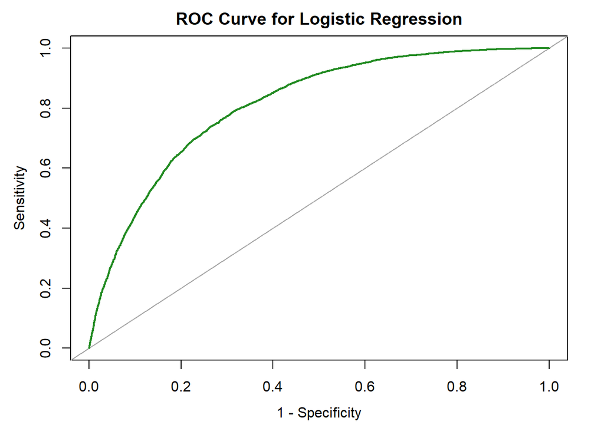

```r
plot(roc_glm, legacy.axes=TRUE, main="ROC Curve for Logistic Regression", asp=0, col="forestgreen")
```

#### Random Forest

```r
rf_md <- randomForest(formula = diabetes_type ~., data= TrainSet_binary, ntree=500)
summary(rf_md)
```

```
##                 Length Class  Mode
## call                 4 -none- call
## type                 1 -none- character
## predicted        63964 factor numeric
## err.rate          1500 -none- numeric
## confusion            6 -none- numeric
## votes           127928 matrix numeric
## oob.times        63964 -none- numeric
## classes              2 -none- character
## importance          10 -none- numeric
## importanceSD         0 -none- NULL
## localImportance      0 -none- NULL
## proximity            0 -none- NULL
## ntree                1 -none- numeric
## mtry                 1 -none- numeric
## forest              14 -none- list
## y                63964 factor numeric
## test                 0 -none- NULL
## inbag                0 -none- NULL
## terms                3 terms  call
```

```r
rf_pred_prob <- predict(rf_md, newdata = TestSet_binary, type="prob")
rf_pred <- ifelse(rf_pred_prob[,"Diabete"] > 0.6, "Diabete", "Non-diabete")
confusionMatrix(as.factor(rf_pred), TestSet_binary$diabetes_type, positive = "Non-diabete")
```

```
## Confusion Matrix and Statistics
##
##              Reference
## Prediction    Non-diabete Diabete
##   Non-diabete        6030    2452
##   Diabete            1965    5543
##
##                Accuracy : 0.7238
##                  95% CI : (0.7168, 0.7307)
##     No Information Rate : 0.5
##     P-Value [Acc > NIR] : < 2.2e-16
##
##                   Kappa : 0.4475
##
##  Mcnemar's Test P-Value : 2.62e-13
##
##             Sensitivity : 0.7542
##             Specificity : 0.6933
##          Pos Pred Value : 0.7109
##          Neg Pred Value : 0.7383
##              Prevalence : 0.5000
##          Detection Rate : 0.3771
##    Detection Prevalence : 0.5305
##       Balanced Accuracy : 0.7238
##
##        'Positive' Class : Non-diabete
##
```

```r
# ROC
roc_rf <- roc(TestSet_binary$diabetes_type, rf_pred_prob[, "Diabete"],
              levels = c("Diabete", "Non-diabete"), direction = ">")

# AUC
auc_rf <- auc(roc_rf)
print(auc_rf)
```

```
## Area under the curve: 0.7969
```

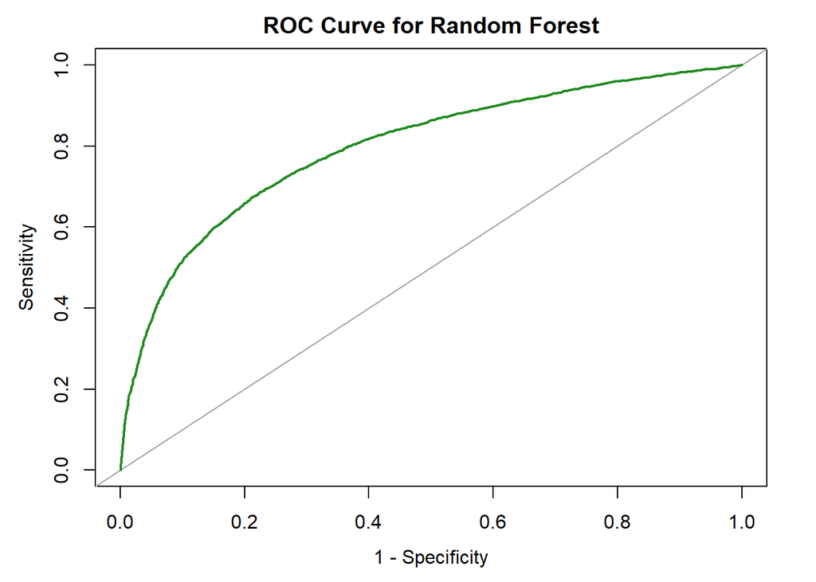

```r
plot(roc_rf, legacy.axes=TRUE, main="ROC Curve for Random Forest", col="forestgreen" , asp=0)
```

#### NaiveBayes

```r
nb_md <- NaiveBayes(formula = diabetes_type ~ ., data = TrainSet_binary)
summary(nb_md)
```

```
##           Length Class      Mode
## apriori    2     table      numeric
## tables    10     -none-     list
## levels     2     -none-     character
## call       3     -none-     call
## x         10     data.frame list
## usekernel  1     -none-     logical
## varnames  10     -none-     character
```

```r
nb_pred_prob <- predict(nb_md, newdata = TestSet_binary, type="raw")$posterior
nb_pred <- ifelse(nb_pred_prob[, "Diabete"] > 0.6, "Diabete", "Non-diabete")
confusionMatrix(as.factor(nb_pred),TestSet_binary$diabetes_type)
```

```
## Confusion Matrix and Statistics
##
##              Reference
## Prediction    Non-diabete Diabete
##   Non-diabete        6301    2961
##   Diabete            1694    5034
##
##                Accuracy : 0.7089
##                  95% CI : (0.7018, 0.7159)
##     No Information Rate : 0.5
##     P-Value [Acc > NIR] : < 2.2e-16
##
##                   Kappa : 0.4178
##
##  Mcnemar's Test P-Value : < 2.2e-16
##
##             Sensitivity : 0.7881
##             Specificity : 0.6296
##          Pos Pred Value : 0.6803
##          Neg Pred Value : 0.7482
##              Prevalence : 0.5000
##          Detection Rate : 0.3941
##    Detection Prevalence : 0.5792
##       Balanced Accuracy : 0.7089
##
##        'Positive' Class : Non-diabete
##
```

```r
roc_nb <- roc(TestSet_binary$diabetes_type, nb_pred_prob[, "Diabete"],
              levels = c("Diabete", "Non-diabete"), direction = ">")

auc_nb <- auc(roc_nb)
print(auc_nb)
```

```
## Area under the curve: 0.7947
```

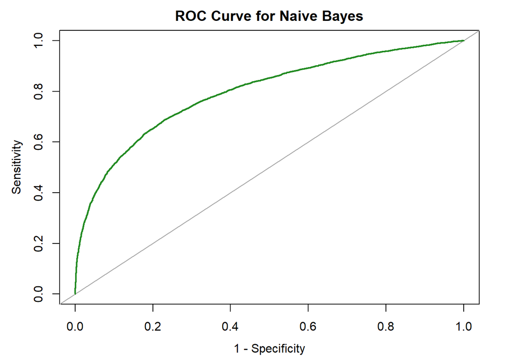

```r
plot(roc_nb, legacy.axes=TRUE, main = "ROC Curve for Naive Bayes", col = "forestgreen", asp=0)
```

### Conclusion

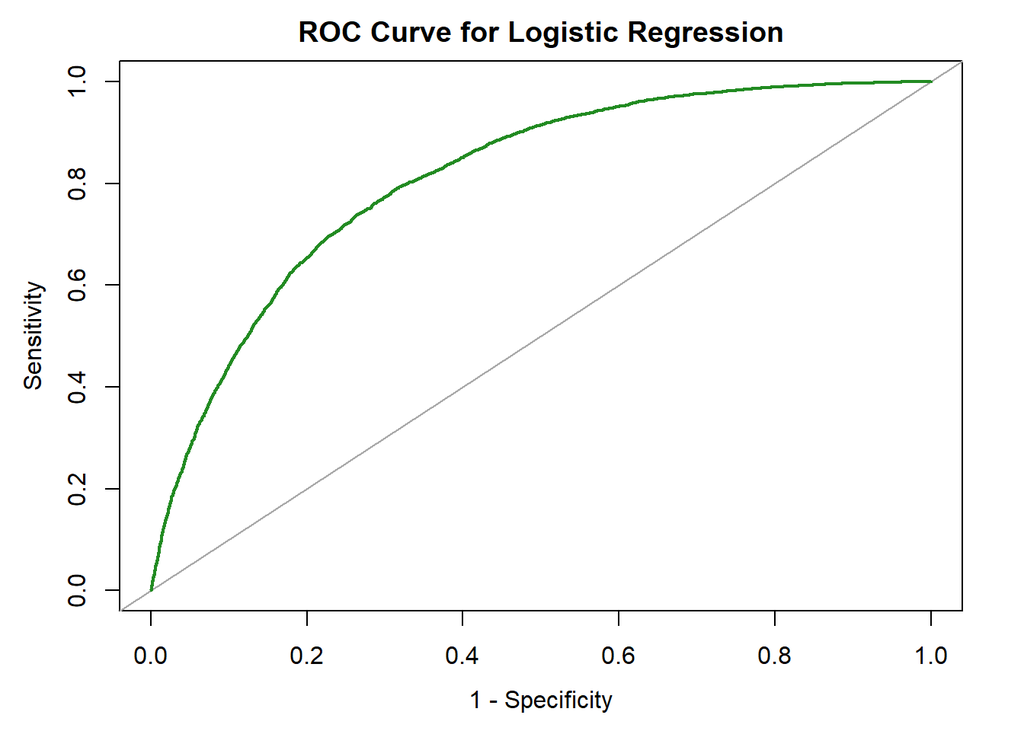

```
## Area under the curve: 0.8113
```

Hiệu suất phân loại của mô hình đạt chỉ số đánh giá tốt > 0.8. Hoàn toàn có thể tin tưởng.